# Amniotic Testosterone & Autistic Traits in Adolescence

Niamh Dooley

# Introduction

This R-code was written by Niamh Dooley (niamhdooley@rcsi.com) and analyzes data from the Longitudinal Foetal Testosterone Study in Cambridge (PI: Prof. Simon Baron-Cohen)

*Data Imported:* Two waves of the FT longitudinal study were used in this analysis, referred to as the 2013 & 2016 waves. Imported here are those that met inclusion criteria (valid pT value, at least one AQ questionnaire completed, no genetic abnormalities).

# Load libraries & data

```r
library(tidyverse)
library(tidyr)
library(broom)
library(knitr)
library(lme4)
library(ggplot2); theme_set(theme_minimal())
library(readxl)
library(RColorBrewer)
library(dvmisc)
library(ggeffects)
library(stargazer)
library(ggpubr)
library(dplyr)
library(qwraps2)
library(emmeans)
library(gridExtra)
library(MASS)
library(effects)
library(sjmisc)
library(lsr)
```

```r
load("/Users/niamhdooley/OneDrive - Royal College of Surgeons in Ireland/AAAPhD/Cambridge/ft/FT behavioural/R_Scripts/FT-autism/ftdata.Rda")

head(smallft)
```

```
##   ID GENDER AGE_YRS AGE_MTHS fT_NUM gen_puberty_score AQ_chrep AQ_parrep
## 1 11    boy      13      160   0.65               2.4       13         3
## 2 15    boy      16      194   0.79               3.0       19        17
## 3 24    boy      15      182   1.25               2.8       15         5
## 4 26   girl      15      184   0.40               3.6       14         6
## 5 28    boy      15      186   1.10               2.8       20         7
## 6 32   girl      16      197   0.35               3.6       23        10
##   chAQ_fullscale parAQ_fullscale chAQ_H1 chAQ_H2 parAQ_H1 parAQ_H2 chAQ_SBC1
## 1             16               4       4      12        2        2         0
## 2             26              20      18       8       16        4         4
## 3             18               8      13       5        6        2         1
## 4             17               9       8       9        3        6         0
## 5             21               9      19       2        5        4         5
## 6             29              14      22       7        7        7         2
##   chAQ_SBC2 chAQ_SBC3 chAQ_SBC4 chAQ_SBC5 parAQ_SBC1 parAQ_SBC2 parAQ_SBC3
## 1         3         0         1         9          0          0          0
## 2         4         5         1         5          1          5          2
## 3         4         2         3         5          0          1          0
## 4         4         1         2         7          0          1          1
## 5         5         3         5         2          0          2          1
## 6         7         5         3         6          1          1          0
##   parAQ_SBC4 parAQ_SBC5 female_agemenarche_yr female_agemenarche_mth GA mat.age
## 1          1          2                    NA                     NA 17      31
## 2          6          3                    NA                     NA NA      NA
## 3          3          1                    NA                     NA 17      25
## 4          0          4                    12                      1 NA      30
## 5          1          3                    NA                     NA 17      35
## 6          2          6                    13                      8 16      36
```

```r
# fT_NUM: amniotic testosterone concentration (nmol/L)
# gen_puberty_score: pubertal stage as determined by the Pubertal Development Scale (Peterson, 1988)
# AQ_chrep: child-report AQ total score (from the Adult AQ; Baron-Cohen et al.,2002)
# AQ_parrep: parent-report AQ total score (from the Adolescent AQ; Baron-Cohen et al.,2006)
# SBC1-5 refer to the subscales social skills, attention switching, communication, imagination & attention to detail
```

# Explore & Clean data

## Age

One individual was missing age. Their age were mean imputed.

```r
# find subjects with missing ages
miss_age = sum(is.na(smallft$AGE_MTHS)) # n=1
miss_age_ids = which(is.na(smallft$AGE_MTHS))

# Mean Impute...
smallft$AGE_MTHS.imp <- smallft$AGE_MTHS
for(i in 1:length(miss_age_ids)) {
  smallft$AGE_MTHS.imp[miss_age_ids[i]] = mean(smallft$AGE_MTHS, na.rm = TRUE)
  }
smallft <- move_columns(smallft, AGE_MTHS.imp, .after = "AGE_MTHS")

# use this mean-imputed age (in months) variable (AGE_MTHS.imp) for analysis
smallft$agemz <- scale(smallft$AGE_MTHS.imp)
```

## Prenatal Testosterone

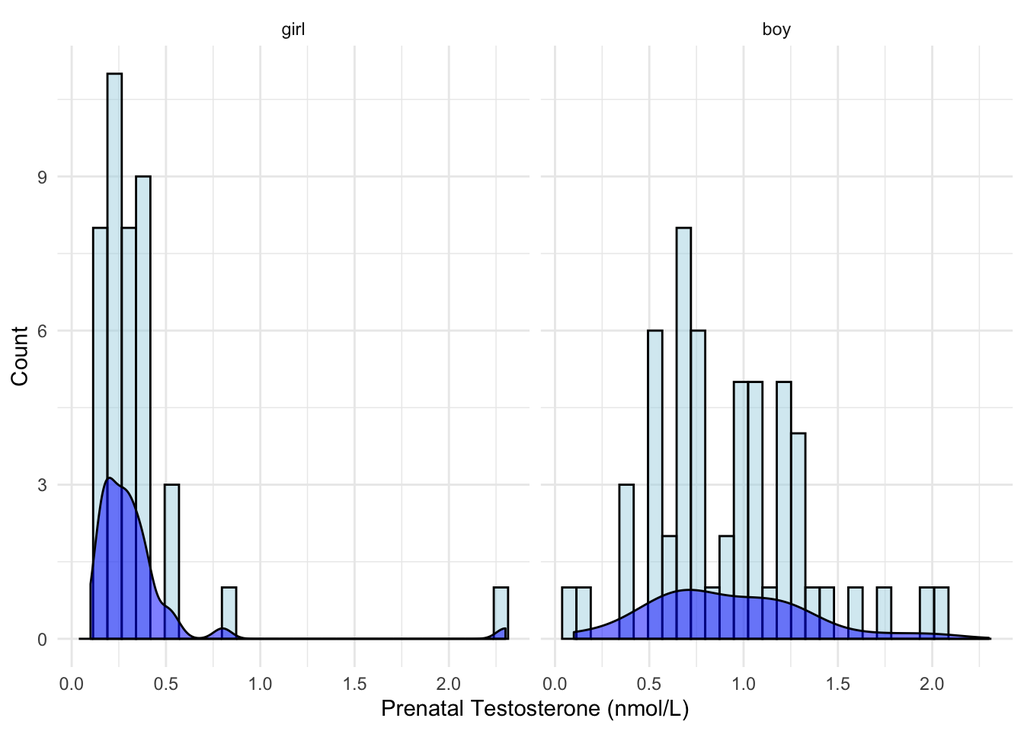

```r
ggplot(data = smallft, aes(x = fT_NUM) )+
  geom_histogram(aes(x=fT_NUM), alpha=0.5, colour="black",
                 fill = "lightblue") +
  geom_density(alpha = 0.5, fill = "blue") +
  labs(y = "Count", x = "Prenatal Testosterone (nmol/L)") +
  scale_fill_brewer(palette = "Set1") +
  theme_minimal()+
  theme(legend.title = element_blank())+
  facet_grid(~GENDER)
```

Histograms above show a female participant with a pT value way outside the typical female range. We decided to exclude her from the analysis.

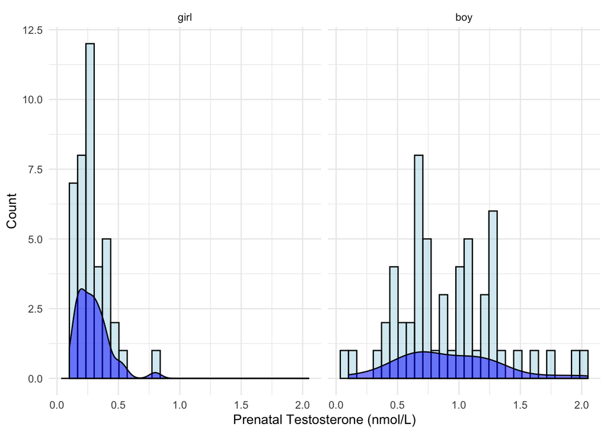

```r
 rows <- which(smallft$fT_NUM==2.3)
  smallft <- smallft[-c(rows), ]

# re-create histograms again
ggplot(data = smallft, aes(x = fT_NUM) )+
  geom_histogram(aes(x=fT_NUM), alpha=0.5, colour="black",
                 fill = "lightblue") +
  geom_density(alpha = 0.5, fill = "blue") +
  labs(y = "Count", x = "Prenatal Testosterone (nmol/L)") +
  scale_fill_brewer(palette = "Set1") +
  theme_minimal()+
  theme(legend.title = element_blank())+
  facet_grid(~GENDER)
```

## Pubertal stage

From PDS questionnaire. Note male mean PDS score is the ave of items on (1) height (2) body hair (3)skin (4)voice-drop (5)facial hair

While female mean PDS score reflects items on: (1)height (2)body hair (3)skin (4)breasts (5)menstruation (y/n)

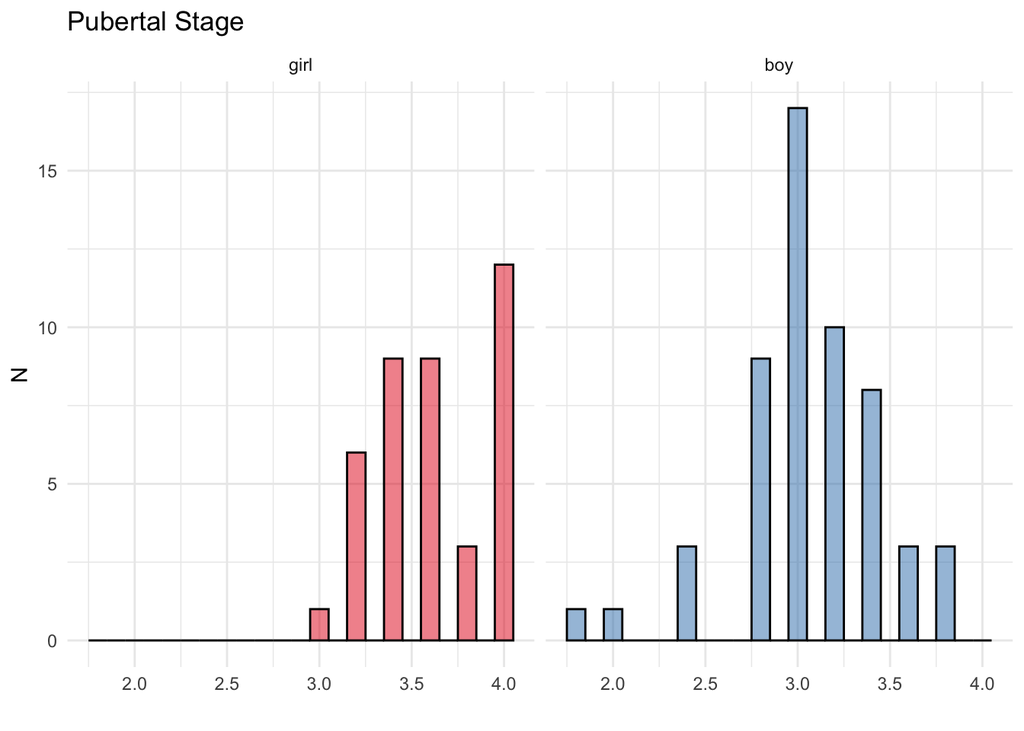

```r
# distribution of PDS stage for males & females separately
ggplot(data = smallft, aes(x = gen_puberty_score, fill=GENDER)) +
  geom_histogram(color="black", binwidth=0.10, alpha=0.5) +
  labs(y = "N", x = " ", title= "Pubertal Stage") +
  facet_wrap(~GENDER)  +
  theme_minimal() +
  scale_fill_brewer(palette = "Set1") +
  theme(legend.position="none")
```

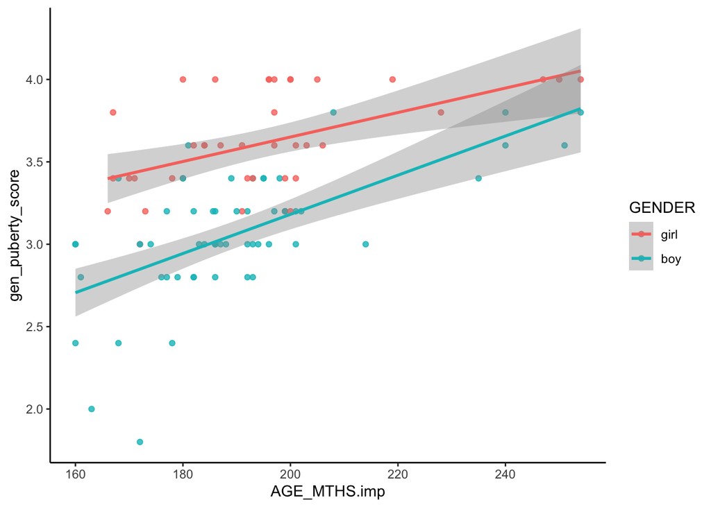

```r
# what is the r'ship between pubertal stage and age (for boys & girls)?

ggplot(smallft, aes(AGE_MTHS.imp , gen_puberty_score, colour=GENDER)) +
  geom_point(aes(colour=GENDER), alpha = 0.8) +
  theme_classic()+
  geom_smooth(method = 'lm', formula= y~x)
```

```r
# within-sex correlations
boys <- smallft[smallft$GENDER=="boy",]
girls <- smallft[smallft$GENDER=="girl",]

cor(x=boys$gen_puberty_score, y=boys$AGE_MTHS.imp, use="complete.obs") # male r=.64
```

```
## [1] 0.6376187
```

```r
cor(x=girls$gen_puberty_score, y=girls$AGE_MTHS.imp, use="complete.obs") # female r=.51
```

```
## [1] 0.5074126
```

## Pubertal Timing

Create pubertal timing variables as per https://www.ncbi.nlm.nih.gov/pmc/articles/PMC2756189/

```r
# steps:
# create sex-specific dataset for puberty analysis
  # remove all NA cases of puberty score
  # compute age (agemz) ~ PDS stage (gen_puberty_score), extract residuals lm[["residuals"]] and add to df as a variable

# Males
boys <- smallft[smallft$GENDER=="boy",]
rows <-which(is.na(boys$gen_puberty_score))
if (!is_empty(rows)) {
boys <- boys[-c(rows), ]}

mod <- lm(gen_puberty_score ~ agemz, data=boys)
boys$pub.timing <- mod$residuals
boys <- move_columns(boys, pub.timing, .after = "gen_puberty_score")

# Females
girls <- smallft[smallft$GENDER=="girl",]
rows <-which(is.na(girls$gen_puberty_score))
if (!is_empty(rows)) {
girls <- girls[-c(rows), ]}

mod <- lm(gen_puberty_score ~ agemz, data=girls)
girls$pub.timing <- mod$resid
girls <- move_columns(girls, pub.timing, .after = "gen_puberty_score")

# put male and female df's together into 1 df
ft4pub <- rbind(boys, girls)

# using a loop, copy pub.timing data back into the main df "smallft" (issues using direct merge due to missing puberty data)
smallft$pub.timing <- NA
for (i in 1:length(smallft$ID)) {
  row <- which(ft4pub$ID == smallft$ID[i])
  if (!is_empty(row)) {
  smallft$pub.timing[i] <-ft4pub$pub.timing[row]}
}
smallft <- move_columns(smallft, pub.timing, .before = "gen_puberty_score")
```

## Standardize/centre variables

```r
# pubertal stage (note pubertal timing is already a z-score)
smallft$pub.stage <- smallft$gen_puberty_score
smallft$pub.stage.z <- scale(smallft$gen_puberty_score, center = T, scale=F)

smallft$mat.age.z <- scale(smallft$mat.age, center = T, scale=F)
smallft$GA.z <- scale(smallft$GA, center = T, scale=F)
smallft$ftz <- scale(smallft$fT_NUM)
```

# Descriptives

| Sample Summary | Full Sample | Girls | Boys |
| --- | --- | --- | --- |
| **Age (years)** |  |  |  |
| Min | 13 | 13 | 13 |
| Max | 21 | 21 | 21 |
| Mean (SD) | 95; 15.60 (1.78) | 15.80 (1.80) | 55; 15.46 (1.77) |
| **Maternal Age (years)** |  |  |  |
| Min | 23 | 25 | 23 |
| Max | 45 | 45 | 45 |
| Mean (SD) | 73; 34.96 (4.75) | 30; 35.87 (4.36) | 43; 34.33 (4.96) |
| **GA @ amnio** |  |  |  |
| Min | 14 | 15 | 14 |
| Max | 21 | 18 | 21 |
| Mean (SD) | 50; 16.64 (1.48) | 15; 16.47 (1.06) | 35; 16.71 (1.64) |
| **Stage of Puberty** |  |  |  |
| Min | 1.8 | 3.0 | 1.8 |
| Max | 4 | 4.0 | 3.8 |
| Mean (SD) | 95; 3.30 (0.45) | 40; 3.62 (0.31) | 55; 3.07 (0.39) |
| **Puberty Timing** |  |  |  |
| Min | -1.04864 | -0.4506405 | -1.0486402 |
| Max | 0.6444229 | 0.4978616 | 0.6444229 |
| Mean (SD) | 95; 0.00 (0.29) | 40; 0.00 (0.27) | 55; 0.00 (0.30) |
| **Foetal Testosterone levels (nmol/L)** |  |  |  |
| Min | 0.1 | 0.15 | 0.10 |
| Max | 2.05 | 0.80 | 2.05 |
| Mean (SD) | 96; 0.66 (0.45) | 40; 0.29 (0.13) | 56; 0.92 (0.41) |
| **Autism Quotient (self-report)** |  |  |  |
| Min | 4 | 6 | 4 |
| Max | 39 | 27 | 39 |
| Mean (SD) | 86; 16.23 (6.71) | 39; 14.67 (5.54) | 47; 17.53 (7.35) |
| **Autism Quotient (parent-report)** |  |  |  |
| Min | 3 | 4 | 3 |
| Max | 40 | 15 | 40 |
| Mean (SD) | 85; 12.98 (8.11) | 35; 9.06 (2.97) | 50; 15.72 (9.38) |
| **SOCIAL (self-report)** |  |  |  |
| Min | 0 | 0 | 0 |
| Max | 10 | 7 | 10 |
| Mean (SD) | 2.34 (2.35) | 1.87 (1.85) | 2.72 (2.65) |
| **SOCIAL (parent-report)** |  |  |  |
| Min | 0 | 0 | 0 |
| Max | 10 | 3 | 10 |
| Mean (SD) | 2.01 (2.40) | 0.91 (0.98) | 2.78 (2.78) |
| **ATT-SWITCH (self-report)** |  |  |  |
| Min | 0 | 0 | 1 |
| Max | 10 | 7 | 10 |
| Mean (SD) | 4.08 (2.00) | 3.67 (1.75) | 4.43 (2.14) |
| **ATT-SWITCH (parent-report)** |  |  |  |
| Min | 0 | 0 | 0 |
| Max | 9 | 5 | 9 |
| Mean (SD) | 2.86 (2.09) | 2.09 (1.48) | 3.40 (2.29) |
| **COMMUNIC (self-report)** |  |  |  |
| Min | 0 | 0 | 0 |
| Max | 8 | 6 | 8 |
| Mean (SD) | 2.23 (2.00) | 1.79 (1.92) | 2.60 (2.01) |
| **COMMUNIC (parent-report)** |  |  |  |
| Min | 0 | 0 | 0 |
| Max | 10 | 6 | 10 |
| Mean (SD) | 2.01 (2.20) | 1.17 (1.22) | 2.60 (2.53) |
| **IMAGIN (self-report)** |  |  |  |
| Min | 0 | 0 | 0 |
| Max | 7 | 6 | 7 |
| Mean (SD) | 2.50 (1.73) | 2.05 (1.43) | 2.87 (1.87) |
| **IMAGIN (parent-report)** |  |  |  |
| Min | 0 | 0 | 0 |
| Max | 9 | 4 | 9 |
| Mean (SD) | 2.08 (1.96) | 0.94 (0.94) | 2.88 (2.10) |
| **DETAIL (self-report)** |  |  |  |
| Min | 0 | 1 | 0 |
| Max | 9 | 9 | 9 |
| Mean (SD) | 5.08 (2.17) | 5.28 (2.10) | 4.91 (2.22) |
| **DETAIL (parent-report)** |  |  |  |
| Min | 0 | 1 | 0 |
| Max | 9 | 9 | 9 |
| Mean (SD) | 4.01 (2.19) | 3.94 (1.89) | 4.06 (2.39) |

# Create long format df

```r
ftl = reshape(smallft, varying = list(c("AQ_chrep", "AQ_parrep"),
                                    c("chAQ_fullscale", "parAQ_fullscale"),
                                    c("chAQ_H1", "parAQ_H1"),
                                    c("chAQ_H2", "parAQ_H2"),
                                    c("chAQ_SBC1", "parAQ_SBC1"),
                                    c("chAQ_SBC2", "parAQ_SBC2"),
                                    c("chAQ_SBC3", "parAQ_SBC3"),
                                    c("chAQ_SBC4", "parAQ_SBC4"),
                                    c("chAQ_SBC5", "parAQ_SBC5")),
               v.names =c("AQ","AQ_fullvar", "AQ_H1", "AQ_H2", "SOCIAL","ATT_SWITCH","COMMUNIC","IMAGIN","DETAIL"),
               idvar = "ID",
               timevar = "rater",
               direction="long")

ftl <- ftl %>%
            mutate(
              rater = factor(rater,
                      levels = c (1,2),
                      labels = c("self", "parent")),
              ID = factor(ID))
```

# Plot AQ distributions

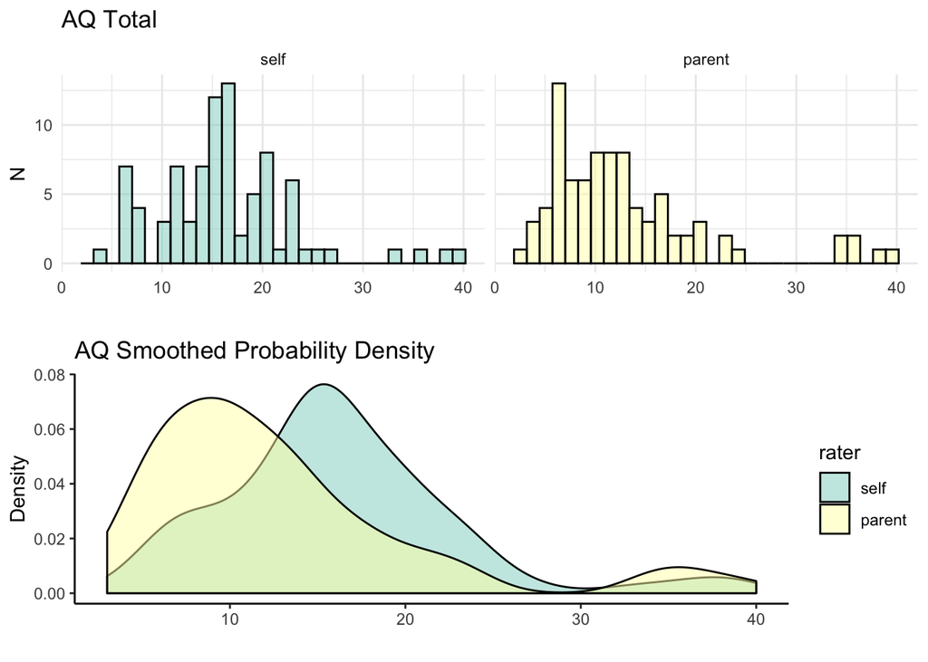

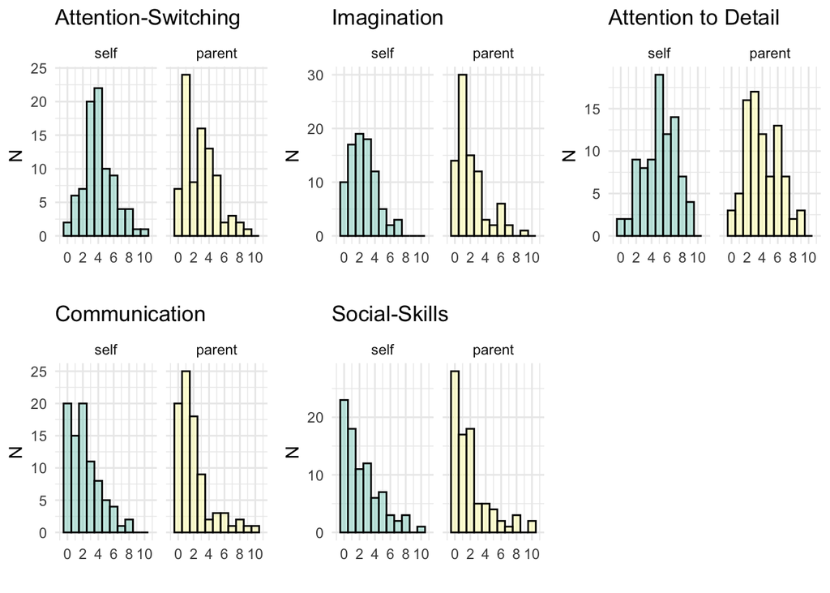

# AQ total analysis

```r
# name dataset "d"
d = ftl

# set contrast for binary vars (had to repeat within lmer function)
contrasts(d$GENDER) <- c(-.5, .5)
contrasts(d$rater)  <- c(-.5, .5)
```

Analysis of AQ scores consisted of 3 consecutive models.

The first model (a) includes pT, sex, interaction pT-x-sex, pubertal factor, interaction pubertal factor-x-pT and the within-subject variable of rater (parent/teen)

Model (b) adjusts for maternal age at time of birth

Model (c) adjusts for the time of amniocentesis (gestational age in weeks)

These models were run separately due to the drop off in N due to missing data for maternal age and time of amnio.

```r
# pubertal stage model
M1a.AQ.gauss <- lmer(AQ ~ ftz  + GENDER  + ftz:GENDER + rater
                     + pub.stage.z + ftz:pub.stage.z
                     + (1 | ID),
                    data = d,
                    contrasts=list(GENDER=c(-0.5,0.5), rater=c(-0.5,0.5)))

M1b.AQ.gauss <- lmer(AQ ~ ftz  + GENDER  + ftz:GENDER + rater
                     + pub.stage.z + ftz:pub.stage.z
                     + mat.age
                     + (1 | ID),
                    data = d,
                    contrasts=list(GENDER=c(-0.5,0.5), rater=c(-0.5,0.5)))

M1c.AQ.gauss <- lmer(AQ ~ ftz  + GENDER  + ftz:GENDER + rater
                     + pub.stage.z + ftz:pub.stage.z
                     + mat.age + GA
                     + (1 | ID),
                    data = d,
                    contrasts=list(GENDER=c(-0.5,0.5), rater=c(-0.5,0.5)))

# as above but with uncentred pubertal stage (for plots)
M1b.AQ.gauss_ <- lmer(AQ ~ ftz  + GENDER + rater + pub.stage
                     + ftz:GENDER
                     + ftz:pub.stage
                     + mat.age
                     + (1 | ID),
                    data = d,
                    contrasts=list(GENDER=c(-0.5,0.5), rater=c(-0.5,0.5)))

stargazer(M1a.AQ.gauss, M1b.AQ.gauss, M1c.AQ.gauss,  report=('vcstp'), digits = 2, digit.separator = "", order = c(), align = TRUE,  type = "text", title="PUBERTAL STAGE MODEL")
```

```
##
## PUBERTAL STAGE MODEL
## ====================================================
##                           Dependent variable:
##                     --------------------------------
##                                    AQ
##                        (1)        (2)        (3)
## ----------------------------------------------------
## ftz                   -0.92      -0.32      -1.77
##                       (1.67)     (1.86)     (4.09)
##                     t = -0.55  t = -0.17  t = -0.43
##                      p = 0.59   p = 0.87   p = 0.67
##
## GENDER1                7.44       5.17       5.41
##                       (3.12)     (3.39)     (8.29)
##                      t = 2.38   t = 1.52   t = 0.65
##                      p = 0.02   p = 0.13   p = 0.52
##
## rater1                -3.61      -3.53      -3.09
##                       (0.83)     (0.91)     (1.25)
##                     t = -4.36  t = -3.86  t = -2.46
##                     p = 0.0001 p = 0.0002  p = 0.02
##
## pub.stage.z            2.50       1.42      -1.92
##                       (1.79)     (2.01)     (2.65)
##                      t = 1.40   t = 0.71  t = -0.72
##                      p = 0.17   p = 0.48   p = 0.47
##
## mat.age                          -0.01      -0.12
##                                  (0.16)     (0.20)
##                                t = -0.05  t = -0.58
##                                 p = 0.96   p = 0.56
##
## GA                                          -2.07
##                                             (0.61)
##                                           t = -3.37
##                                           p = 0.001
##
## ftz:GENDER1            1.63       2.04       9.02
##                       (3.49)     (3.74)     (8.05)
##                      t = 0.47   t = 0.55   t = 1.12
##                      p = 0.64   p = 0.59   p = 0.27
##
## ftz:pub.stage.z        3.74       5.36       9.67
##                       (2.30)     (2.48)     (3.14)
##                      t = 1.63   t = 2.16   t = 3.08
##                      p = 0.11   p = 0.04  p = 0.003
##
## Constant              14.28      14.84      51.46
##                       (1.50)     (5.56)    (14.68)
##                      t = 9.52   t = 2.67   t = 3.51
##                      p = 0.00   p = 0.01  p = 0.0005
##
## ----------------------------------------------------
## Observations           170        139         94
## Log Likelihood       -551.18    -447.11    -297.53
## Akaike Inf. Crit.    1120.35     914.22     617.05
## Bayesian Inf. Crit.  1148.57     943.57     645.03
## ====================================================
## Note:                    *p<0.1; **p<0.05; ***p<0.01
```

```r
# pubertal timing model
M2a.AQ.gauss <- lmer(AQ ~ ftz  + GENDER  + ftz:GENDER + rater
                     + pub.timing + ftz:pub.timing
                     + (1 | ID),
                    data = d,
                    contrasts=list(GENDER=c(-0.5,0.5), rater=c(-0.5,0.5)))

M2b.AQ.gauss <- lmer(AQ ~ ftz  + GENDER  + ftz:GENDER + rater
                     + pub.timing + ftz:pub.timing
                     + mat.age
                     + (1 | ID),
                    data = d,
                    contrasts=list(GENDER=c(-0.5,0.5), rater=c(-0.5,0.5)))

M2c.AQ.gauss <- lmer(AQ ~ ftz  + GENDER  + ftz:GENDER + rater
                     + pub.timing + ftz:pub.timing
                     + mat.age + GA
                     + (1 | ID),
                    data = d,
                    contrasts=list(GENDER=c(-0.5,0.5), rater=c(-0.5,0.5)))

stargazer(M2a.AQ.gauss, M2b.AQ.gauss, M2c.AQ.gauss,  report=('vcstp'), digits = 2, digit.separator = "", order = c(), align = TRUE,    type = "text", title="PUBERTAL TIMING MODEL")
```

```
##
## PUBERTAL TIMING MODEL
## ===================================================
##                           Dependent variable:
##                     -------------------------------
##                                   AQ
##                        (1)        (2)        (3)
## ---------------------------------------------------
## ftz                   -0.98      -0.41      -1.87
##                       (1.65)     (1.82)    (3.99)
##                     t = -0.60  t = -0.22  t = -0.47
##                      p = 0.56   p = 0.83  p = 0.64
##
## GENDER1                6.13       4.35      6.30
##                       (2.94)     (3.17)    (7.64)
##                      t = 2.08   t = 1.37  t = 0.82
##                      p = 0.04   p = 0.17  p = 0.41
##
## rater1                -3.67      -3.54      -3.13
##                       (0.83)     (0.92)    (1.26)
##                     t = -4.43  t = -3.86  t = -2.49
##                     p = 0.0000 p = 0.0002 p = 0.02
##
## pub.timing             2.13       1.88      -1.32
##                       (2.14)     (2.21)    (2.65)
##                      t = 1.00   t = 0.85  t = -0.50
##                      p = 0.32   p = 0.40  p = 0.62
##
## mat.age                           0.03      -0.05
##                                  (0.16)    (0.20)
##                                 t = 0.22  t = -0.27
##                                 p = 0.83  p = 0.79
##
## GA                                          -2.02
##                                            (0.59)
##                                           t = -3.44
##                                           p = 0.001
##
## ftz:GENDER1           -0.57      -0.95      3.30
##                       (3.31)     (3.52)    (8.00)
##                     t = -0.17  t = -0.27  t = 0.41
##                      p = 0.87   p = 0.79  p = 0.68
##
## ftz:pub.timing         5.68       6.91      10.59
##                       (2.45)     (2.60)    (3.10)
##                      t = 2.32   t = 2.65  t = 3.41
##                      p = 0.03   p = 0.01  p = 0.001
##
## Constant              14.30      13.29      48.75
##                       (1.47)     (5.51)    (14.23)
##                      t = 9.72   t = 2.41  t = 3.43
##                      p = 0.00   p = 0.02  p = 0.001
##
## ---------------------------------------------------
## Observations           170        139        94
## Log Likelihood       -550.07    -445.87    -296.63
## Akaike Inf. Crit.    1118.14     911.74    615.26
## Bayesian Inf. Crit.  1146.36     941.08    643.24
## ===================================================
## Note:                   *p<0.1; **p<0.05; ***p<0.01
```

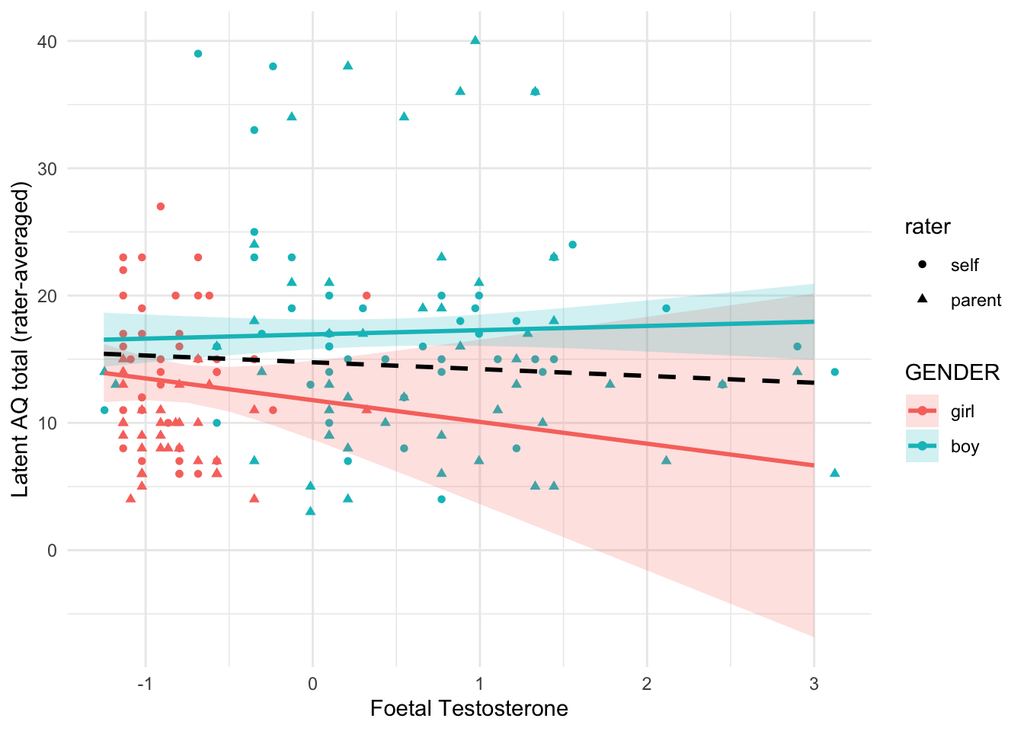

```r
# Use model (b) to plot results to balance sample size with control of confounds

# EMMs for main effect of ft
main.predicted <- effect(c("ftz"), M1b.AQ.gauss,
                       xlevels= list(ftz = seq(from=-1.25, to=3, by=0.25)),
                       se=TRUE, confidence.level = .95,
                       typical=mean)
main.pred <- as.data.frame(main.predicted)

# EMMs for main effect of ft for each sex
predicted.sex <- effect(c("ftz", "GENDER"), M1b.AQ.gauss,
                       xlevels= list(ftz = seq(from=-1.25, to=3, by=0.25)),
                       se=TRUE, confidence.level = .95,
                       typical=mean)
pred.sex <- as.data.frame(predicted.sex)
pred.sex$GENDER = relevel(pred.sex$GENDER, "girl")

ggplot()+
  geom_point(data = d,
              aes(x = ftz, y = AQ, colour = GENDER, shape=rater))+
  geom_ribbon(data = pred.sex, aes(x = ftz, ymin = fit - se, ymax = fit + se,
              group=GENDER, fill=GENDER), alpha = 0.2) +
  geom_line(data = pred.sex, aes(x = ftz, y = fit,
              group = GENDER, colour=GENDER),size=1) +
  geom_line(data = main.pred, aes(x =ftz, y = fit),size=1, linetype="dashed") +
  labs(x = "Foetal Testosterone", y = "Latent AQ total (rater-averaged)") +
  theme_minimal()
```

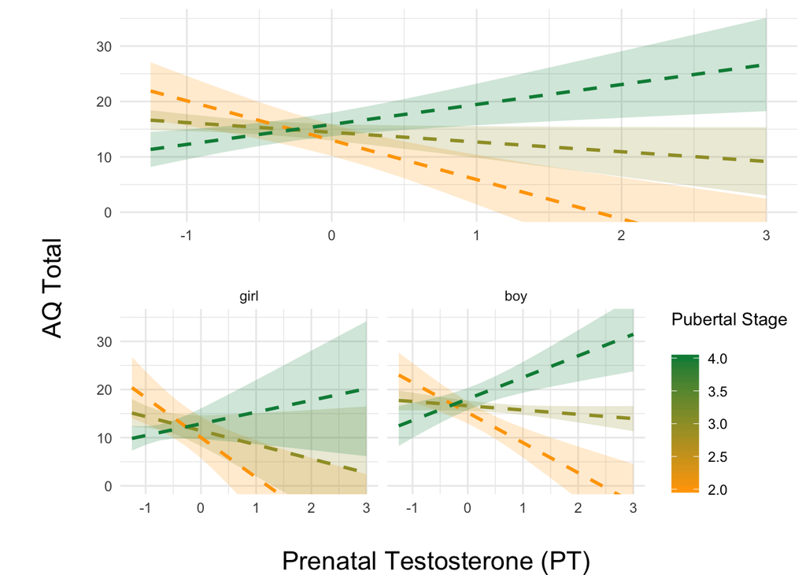

```r
predicted <- effect(c("ftz", "pub.stage"), M1b.AQ.gauss_,
                       xlevels= list(ftz = seq(from=-1.25, to=3, by=0.25),
                                     pub.stage = seq(from=2, to=4, by=1)),
                       se=TRUE, confidence.level = .95,
                       typical=mean)
pred <- as.data.frame(predicted)

predicted.sex <- effect(c("ftz", "GENDER", "pub.stage"), M1b.AQ.gauss_,
                       xlevels= list(ftz = seq(from=-1.25, to=3, by=0.25),
                                     pub.stage = seq(from=2, to=4, by=1)),
                       se=TRUE, confidence.level = .95,
                       typical=mean)
pred.sex <- as.data.frame(predicted.sex)
pred.sex$GENDER = relevel(pred.sex$GENDER, "girl")

gsex <- ggplot()+
  geom_ribbon(data = pred.sex, aes(x = ftz, ymin = fit - se, ymax = fit + se,
              group=pub.stage, fill=pub.stage), alpha = 0.2) +
  geom_line(data = pred.sex, aes(x = ftz, y = fit,
              group = pub.stage, colour=pub.stage),size=1, linetype="dashed") +
  labs(x = "", y = "", fill = "Pubertal Stage\n", colour="Pubertal Stage\n") +
  theme_minimal()+
  coord_cartesian(ylim = c(0,35)) +
  scale_colour_gradient(low="orange", high="springgreen4")+
  scale_fill_gradient(low="orange", high="springgreen4")+
  facet_grid(~GENDER)

gfull<-ggplot()+
  geom_ribbon(data = pred, aes(x = ftz, ymin = fit - se, ymax = fit + se,
              group=pub.stage, fill=pub.stage), alpha = 0.2) +
  geom_line(data = pred, aes(x = ftz, y = fit,
              group = pub.stage, colour=pub.stage),size=1, linetype="dashed") +
  labs(x = "", y = "", fill = "Pubertal Stage\n", colour="Pubertal Stage\n") +
  theme_minimal()+
  coord_cartesian(ylim = c(0,35)) +
  scale_colour_gradient(low="orange", high="springgreen4")+
  scale_fill_gradient(low="orange", high="springgreen4")+
  theme(legend.position = "none" )

gboth<-ggarrange(gfull, gsex,nrow=2, ncol=1)
annotate_figure(gboth,
                bottom=text_grob("Prenatal Testosterone (PT)",  size=16),
                 left = text_grob("\nAQ Total", rot=90, size=16))
```

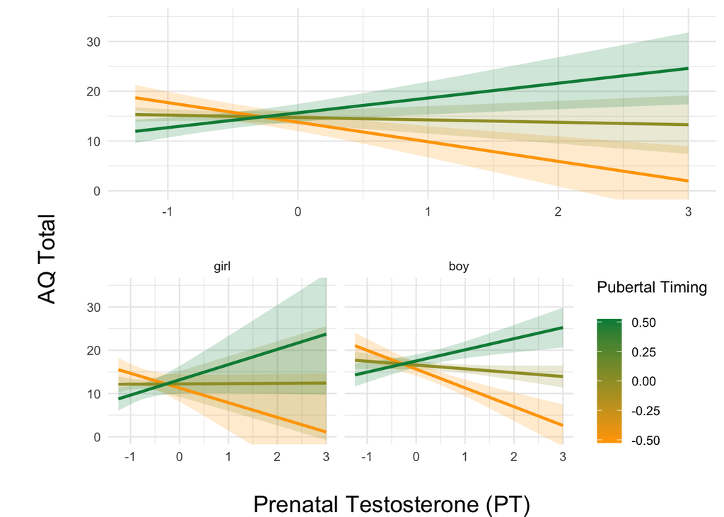

```r
predicted.sex <- effect(c("ftz", "GENDER", "pub.timing"), M2b.AQ.gauss,
                       xlevels= list(ftz = seq(from=-1.25, to=3, by=0.25),
                                     pub.timing = seq(from=-0.5, to=0.5, by=0.5)),
                       se=TRUE, confidence.level = .95,
                       typical=mean)
pred.sex <- as.data.frame(predicted.sex)
pred.sex$GENDER = relevel(pred.sex$GENDER, "girl")

gsex<-ggplot()+
  geom_ribbon(data = pred.sex, aes(x = ftz, ymin = fit - se, ymax = fit + se,
              group=pub.timing, fill=pub.timing), alpha = 0.2) +
  geom_line(data = pred.sex, aes(x = ftz, y = fit,
              group = pub.timing, colour=pub.timing),size=1) +
  labs(x = "", y = "", fill = "Pubertal Timing\n", colour="Pubertal Timing\n") +
  theme_minimal()+
  coord_cartesian(ylim = c(0,35)) +
  scale_colour_gradient(low="orange", high="springgreen4")+
  scale_fill_gradient(low="orange", high="springgreen4")+
  facet_grid(~GENDER)

predicted<- effect(c("ftz",  "pub.timing"), M2b.AQ.gauss,
                       xlevels= list(ftz = seq(from=-1.25, to=3, by=0.25),
                                     pub.timing = seq(from=-0.5, to=0.5, by=0.5)),
                       se=TRUE, confidence.level = .95,
                       typical=mean)
pred <- as.data.frame(predicted)
gfull<-ggplot()+
  geom_ribbon(data = pred, aes(x = ftz, ymin = fit - se, ymax = fit + se,
              group=pub.timing, fill=pub.timing), alpha = 0.2) +
  geom_line(data = pred, aes(x = ftz, y = fit,
              group = pub.timing, colour=pub.timing),size=1) +
  labs(x = "", y = "", fill = "Pubertal Timing\n", colour="Pubertal Timing\n") +
  theme_minimal()+
  coord_cartesian(ylim = c(0,35)) +
  scale_colour_gradient(low="orange", high="springgreen4")+
  scale_fill_gradient(low="orange", high="springgreen4")+
  theme(legend.position = "none" )

gboth<-ggarrange(gfull, gsex,nrow=2, ncol=1)
annotate_figure(gboth,
                bottom=text_grob("Prenatal Testosterone (PT)",  size=16),
                 left = text_grob("\nAQ Total", rot=90, size=16))
```

PT may have a non-linear relationship with AQ. Explore if a quadratic pT term is correlated with AQ and whether plots show a strong non-linearity.

```r
M1a.quad.lmm <- lmer(AQ ~ ftz +  I(ftz^2) + GENDER + rater + pub.stage.z
                     + ftz:GENDER + ftz:pub.stage.z
                     + (1 | ID),
                    data = d,
                    contrasts=list(GENDER=c(-0.5,0.5), rater=c(-0.5,0.5)))
M1b.quad.lmm <- lmer(AQ ~ ftz +  I(ftz^2) + GENDER + rater + pub.stage.z
                     + ftz:GENDER + ftz:pub.stage.z + mat.age
                     + (1 | ID),
                    data = d,
                    contrasts=list(GENDER=c(-0.5,0.5), rater=c(-0.5,0.5)))
M1c.quad.lmm <- lmer(AQ ~ ftz +  I(ftz^2) + GENDER + rater + pub.stage.z
                     + ftz:GENDER + ftz:pub.stage.z + mat.age + GA
                     + (1 | ID),
                    data = d,
                    contrasts=list(GENDER=c(-0.5,0.5), rater=c(-0.5,0.5)))

stargazer(M1a.quad.lmm, M1b.quad.lmm, M1c.quad.lmm, digits = 2, report=('vcsp'), digit.separator = "", order = c(), align = TRUE,    type = "text")
```

```
##
## ====================================================
##                           Dependent variable:
##                     --------------------------------
##                                    AQ
##                        (1)        (2)        (3)
## ----------------------------------------------------
## ftz                   -0.83      -0.03      -1.97
##                       (1.70)     (1.88)     (4.10)
##                      p = 0.63   p = 0.99   p = 0.64
##
## I(ftz2)               -0.34      -0.70      -0.79
##                       (0.70)     (0.71)     (0.89)
##                      p = 0.63   p = 0.33   p = 0.38
##
## GENDER1                7.63       5.48       6.73
##                       (3.16)     (3.41)     (8.43)
##                      p = 0.02   p = 0.11   p = 0.43
##
## rater1                -3.61      -3.52      -3.09
##                       (0.83)     (0.91)     (1.26)
##                     p = 0.0001 p = 0.0002  p = 0.02
##
## pub.stage.z            2.63       1.69      -1.33
##                       (1.82)     (2.03)     (2.73)
##                      p = 0.15   p = 0.41   p = 0.63
##
## mat.age                          -0.005     -0.15
##                                  (0.16)     (0.20)
##                                 p = 0.98   p = 0.47
##
## GA                                          -2.18
##                                             (0.63)
##                                           p = 0.001
##
## ftz:GENDER1            2.59       4.10      11.92
##                       (4.02)     (4.29)     (8.71)
##                      p = 0.52   p = 0.34   p = 0.18
##
## ftz:pub.stage.z        3.67       5.35       9.42
##                       (2.31)     (2.48)     (3.16)
##                      p = 0.12   p = 0.04  p = 0.003
##
## Constant              14.26      14.72      53.91
##                       (1.51)     (5.56)    (14.96)
##                      p = 0.00   p = 0.01  p = 0.0004
##
## ----------------------------------------------------
## Observations           170        139         94
## Log Likelihood       -550.50    -446.05    -296.33
## Akaike Inf. Crit.    1121.00     914.10     616.66
## Bayesian Inf. Crit.  1152.36     946.38     647.18
## ====================================================
## Note:                    *p<0.1; **p<0.05; ***p<0.01
```

```r
M2a.quad.lmm <- lmer(AQ ~ ftz +  I(ftz^2) + GENDER + rater + pub.timing
                     + ftz:GENDER + ftz:pub.timing
                     + (1 | ID),
                    data = d,
                    contrasts=list(GENDER=c(-0.5,0.5), rater=c(-0.5,0.5)))
M2b.quad.lmm <- lmer(AQ ~ ftz +  I(ftz^2) + GENDER + rater + pub.timing
                     + ftz:GENDER + ftz:pub.timing  + mat.age
                     + (1 | ID),
                    data = d,
                    contrasts=list(GENDER=c(-0.5,0.5), rater=c(-0.5,0.5)))
M2c.quad.lmm <- lmer(AQ ~ ftz +  I(ftz^2) + GENDER + rater + pub.timing
                     + ftz:GENDER + ftz:pub.timing  + mat.age + GA
                     + (1 | ID),
                    data = d,
                    contrasts=list(GENDER=c(-0.5,0.5), rater=c(-0.5,0.5)))

stargazer(M2a.quad.lmm, M2b.quad.lmm, M2c.quad.lmm, digits = 2, report=('vcsp'), digit.separator = "", order = c(), align = TRUE,    type = "text")
```

```
##
## ===================================================
##                           Dependent variable:
##                     -------------------------------
##                                   AQ
##                        (1)        (2)        (3)
## ---------------------------------------------------
## ftz                   -0.94      -0.23      -1.96
##                       (1.67)     (1.85)    (4.04)
##                      p = 0.58   p = 0.91  p = 0.63
##
## I(ftz2)               -0.17      -0.46      -0.17
##                       (0.69)     (0.71)    (0.91)
##                      p = 0.81   p = 0.52  p = 0.85
##
## GENDER1                6.19       4.47      6.61
##                       (2.97)     (3.19)    (7.85)
##                      p = 0.04   p = 0.17  p = 0.40
##
## rater1                -3.67      -3.53      -3.12
##                       (0.83)     (0.92)    (1.26)
##                     p = 0.0000 p = 0.0002 p = 0.02
##
## pub.timing             2.19       2.08      -1.17
##                       (2.16)     (2.24)    (2.81)
##                      p = 0.32   p = 0.36  p = 0.68
##
## mat.age                           0.03      -0.06
##                                  (0.16)    (0.20)
##                                 p = 0.83  p = 0.77
##
## GA                                          -2.04
##                                            (0.61)
##                                           p = 0.001
##
## ftz:GENDER1           -0.07       0.45      4.08
##                       (3.89)     (4.13)    (8.94)
##                      p = 0.99   p = 0.92  p = 0.65
##
## ftz:pub.timing         5.62       6.69      10.39
##                       (2.48)     (2.64)    (3.29)
##                      p = 0.03   p = 0.02  p = 0.002
##
## Constant              14.29      13.27      49.23
##                       (1.48)     (5.54)    (14.65)
##                      p = 0.00   p = 0.02  p = 0.001
##
## ---------------------------------------------------
## Observations           170        139        94
## Log Likelihood       -549.50    -445.08    -295.79
## Akaike Inf. Crit.    1118.99     912.17    615.58
## Bayesian Inf. Crit.  1150.35     944.44    646.10
## ===================================================
## Note:                   *p<0.1; **p<0.05; ***p<0.01
```

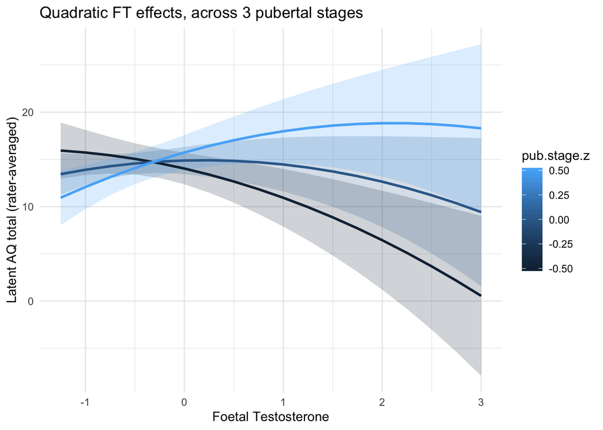

```r
# plot quadratic pT effects
predicted <- as.data.frame(effect(c("ftz", "pub.stage.z"), M1b.quad.lmm,
                xlevels= list(ftz = seq(from=-1.25, to=3, by=0.25),
                             pub.stage.z = seq(from=-0.5, to=0.5, by=0.5)),
                se=TRUE, confidence.level = .95,
                typical=mean))

ggplot()+
  geom_ribbon(data = predicted, aes(x = ftz, ymin = fit - se, ymax = fit + se,
              group=pub.stage.z, fill=pub.stage.z), alpha = 0.2) +
  geom_line(data = predicted, aes(x = ftz, y = fit,
              group = pub.stage.z, colour=pub.stage.z),size=1) +
  labs(x = "Foetal Testosterone", y = "Latent AQ total (rater-averaged)", title = "Quadratic FT effects, across 3 pubertal stages") +
  theme_minimal()
```

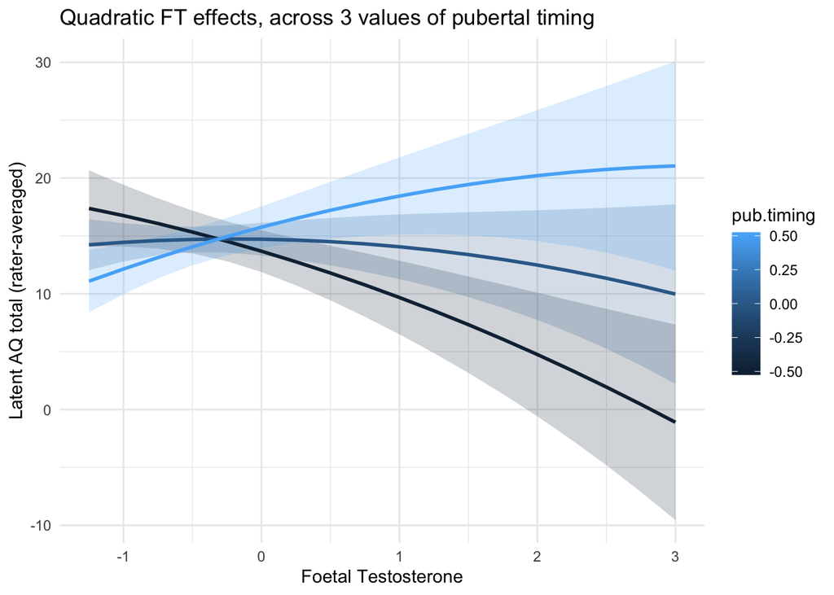

```r
predicted <- as.data.frame(effect(c("ftz", "pub.timing"), M2b.quad.lmm,
                       xlevels= list(ftz = seq(from=-1.25, to=3, by=0.25),
                                     pub.timing = seq(from=-0.5, to=0.5, by=0.5)),
                       se=TRUE, confidence.level = .95,
                       typical=mean))

ggplot()+
  geom_ribbon(data = predicted, aes(x = ftz, ymin = fit - se, ymax = fit + se,
              group=pub.timing, fill=pub.timing), alpha = 0.2) +
  geom_line(data = predicted, aes(x = ftz, y = fit,
              group = pub.timing, colour=pub.timing),size=1) +
  labs(x = "Foetal Testosterone", y = "Latent AQ total (rater-averaged)", title = "Quadratic FT effects, across 3 values of pubertal timing") +
  theme_minimal()
```

## Sensitivity Analysis 1: simpler models

```r
simplerAQ.a <- lmer(AQ ~ ftz  + GENDER
                     + (1 | ID),
                    data = d,
                    contrasts=list(GENDER=c(-0.5,0.5)))
simplerAQ.b <- lmer(AQ ~ ftz*GENDER
                     + (1 | ID),
                    data = d,
                    contrasts=list(GENDER=c(-0.5,0.5)))
simplerAQ.c <- lmer(AQ ~ ftz*GENDER + rater
                     + (1 | ID),
                    data = d,
                    contrasts=list(GENDER=c(-0.5,0.5), rater=c(-0.5,0.5)))

stargazer(simplerAQ.a, simplerAQ.b,simplerAQ.c,report=('vcsp'),
 digits = 2, digit.separator = "",
 order = c(), align = TRUE,    type = "text")
```

```
##
## =================================================
##                          Dependent variable:
##                     -----------------------------
##                                  AQ
##                        (1)      (2)       (3)
## -------------------------------------------------
## ftz                   -0.96    -0.93     -0.92
##                      (0.90)    (1.74)    (1.76)
##                     p = 0.29  p = 0.60  p = 0.61
##
## GENDER1               6.20      6.14      6.42
##                      (1.82)    (3.10)    (3.14)
##                     p = 0.001 p = 0.05  p = 0.05
##
## rater1                                   -3.45
##                                          (0.83)
##                                        p = 0.0001
##
## ftz:GENDER1                    -0.08      0.08
##                                (3.48)    (3.53)
##                               p = 0.99  p = 0.99
##
## Constant              14.27    14.30     14.23
##                      (0.65)    (1.55)    (1.57)
##                     p = 0.00  p = 0.00  p = 0.00
##
## -------------------------------------------------
## Observations           171      171       171
## Log Likelihood       -574.74  -572.58   -564.08
## Akaike Inf. Crit.    1159.48  1157.15   1142.17
## Bayesian Inf. Crit.  1175.19  1176.00   1164.16
## =================================================
## Note:                 *p<0.1; **p<0.05; ***p<0.01
```

```r
rows <- which(d$rater=="self")
d_self <- d[rows,]

rows <- which(d$rater=="parent")
d_parent <- d[rows,]

selfAQ1a <- lm(AQ ~ ftz  + GENDER + pub.stage.z
                     + ftz:GENDER
                     + ftz:pub.stage.z ,
                    data = d_self,
                    contrasts=list(GENDER=c(-0.5,0.5)))
selfAQ1b <- lm(AQ ~ ftz  + GENDER + pub.stage.z
                     + ftz:GENDER
                     + ftz:pub.stage.z + mat.age.z,
                    data = d_self,
                    contrasts=list(GENDER=c(-0.5,0.5)))

selfAQ1c<- lm(AQ ~ ftz  + GENDER + pub.stage.z
                     + ftz:GENDER
                     + ftz:pub.stage.z + mat.age.z + GA.z,
                    data = d_self,
                    contrasts=list(GENDER=c(-0.5,0.5)))


selfAQ2a <- lm(AQ ~ ftz  + GENDER + pub.timing
                     + ftz:GENDER
                     + ftz:pub.timing ,
                    data = d_self,
                    contrasts=list(GENDER=c(-0.5,0.5)))

selfAQ2b <- lm(AQ ~ ftz  + GENDER + pub.timing
                     + ftz:GENDER
                     + ftz:pub.timing + mat.age.z,
                    data = d_self,
                    contrasts=list(GENDER=c(-0.5,0.5)))

selfAQ2c <- lm(AQ ~ ftz  + GENDER + pub.timing
                     + ftz:GENDER
                     + ftz:pub.timing + mat.age.z + GA.z,
                    data = d_self,
                    contrasts=list(GENDER=c(-0.5,0.5)))


stargazer(selfAQ1a,  selfAQ1b, selfAQ1c, report=('vcsp'), digits = 2, digit.separator = "",
 order = c(), align = TRUE,    type = "text")
```

```
##
## ============================================================================
##                                       Dependent variable:
##                     --------------------------------------------------------
##                                                AQ
##                            (1)               (2)                (3)
## ----------------------------------------------------------------------------
## ftz                       -0.85             0.84                4.68
##                          (1.90)            (1.95)              (5.09)
##                         p = 0.66          p = 0.67            p = 0.37
##
## GENDER1                   4.83              0.45               -8.83
##                          (3.53)            (3.56)             (10.22)
##                         p = 0.18          p = 0.90            p = 0.40
##
## pub.stage.z               1.49              0.14               -2.21
##                          (2.05)            (2.16)              (2.45)
##                         p = 0.47          p = 0.95            p = 0.38
##
## mat.age.z                                   0.04                0.05
##                                            (0.17)              (0.19)
##                                           p = 0.80            p = 0.81
##
## GA.z                                                           -2.37
##                                                                (0.58)
##                                                              p = 0.0003
##
## ftz:GENDER1               0.89              0.81               -0.87
##                          (3.96)            (3.91)             (10.07)
##                         p = 0.83          p = 0.84            p = 0.94
##
## ftz:pub.stage.z           3.34              5.80               13.42
##                          (2.60)            (2.52)              (2.91)
##                         p = 0.21          p = 0.03           p = 0.0001
##
## Constant                  16.41             17.14              21.12
##                          (1.71)            (1.72)              (4.97)
##                         p = 0.00          p = 0.00           p = 0.0002
##
## ----------------------------------------------------------------------------
## Observations               86                66                  45
## R2                        0.08              0.10                0.49
## Adjusted R2               0.03              0.01                0.40
## Residual Std. Error  6.62 (df = 80)    5.81 (df = 59)      4.90 (df = 37)
## F Statistic         1.46 (df = 5; 80) 1.11 (df = 6; 59) 5.15*** (df = 7; 37)
## ============================================================================
## Note:                                            *p<0.1; **p<0.05; ***p<0.01
```

```r
stargazer(selfAQ2a,  selfAQ2b, selfAQ2c, report=('vcsp'), digits = 2, digit.separator = "",
 order = c(), align = TRUE,    type = "text")
```

```
##
## ============================================================================
##                                       Dependent variable:
##                     --------------------------------------------------------
##                                                AQ
##                            (1)               (2)                (3)
## ----------------------------------------------------------------------------
## ftz                       -0.90             0.75                5.06
##                          (1.87)            (1.90)              (4.94)
##                         p = 0.64          p = 0.70            p = 0.32
##
## GENDER1                   4.16              0.39               -8.92
##                          (3.35)            (3.34)              (9.65)
##                         p = 0.22          p = 0.91            p = 0.37
##
## pub.timing                0.28              0.64               -2.01
##                          (2.49)            (2.31)              (2.43)
##                         p = 0.91          p = 0.79            p = 0.42
##
## mat.age.z                                   0.09                0.13
##                                            (0.17)              (0.18)
##                                           p = 0.59            p = 0.49
##
## GA.z                                                           -2.29
##                                                                (0.55)
##                                                              p = 0.0002
##
## ftz:GENDER1               -1.03             -2.52              -9.84
##                          (3.75)            (3.67)              (9.92)
##                         p = 0.79          p = 0.50            p = 0.33
##
## ftz:pub.timing            5.73              7.60               14.41
##                          (2.79)            (2.65)              (2.86)
##                         p = 0.05          p = 0.01           p = 0.0001
##
## Constant                  16.40             17.18              21.95
##                          (1.68)            (1.67)              (4.86)
##                         p = 0.00          p = 0.00           p = 0.0001
##
## ----------------------------------------------------------------------------
## Observations               86                66                  45
## R2                        0.11              0.14                0.53
## Adjusted R2               0.05              0.05                0.44
## Residual Std. Error  6.54 (df = 80)    5.68 (df = 59)      4.75 (df = 37)
## F Statistic         1.92 (df = 5; 80) 1.62 (df = 6; 59) 5.85*** (df = 7; 37)
## ============================================================================
## Note:                                            *p<0.1; **p<0.05; ***p<0.01
```

```r
parentAQ1a <- lm(AQ ~ ftz  + GENDER + pub.stage.z
                     + ftz:GENDER
                     + ftz:pub.stage.z ,
                    data = d_parent,
                    contrasts=list(GENDER=c(-0.5,0.5)))

parentAQ1b <- lm(AQ ~ ftz  + GENDER + pub.stage.z
                     + ftz:GENDER
                     + ftz:pub.stage.z + mat.age.z,
                    data = d_parent,
                    contrasts=list(GENDER=c(-0.5,0.5)))

parentAQ1c <- lm(AQ ~ ftz  + GENDER + pub.stage.z
                     + ftz:GENDER
                     + ftz:pub.stage.z + mat.age.z + GA.z,
                    data = d_parent,
                    contrasts=list(GENDER=c(-0.5,0.5)))

parentAQ2a <- lm(AQ ~ ftz  + GENDER  + pub.timing
                     + ftz:GENDER
                     + ftz:pub.timing ,
                    data = d_parent,
                    contrasts=list(GENDER=c(-0.5,0.5)))
parentAQ2b <- lm(AQ ~ ftz  + GENDER  + pub.timing
                     + ftz:GENDER
                     + ftz:pub.timing + mat.age.z,
                    data = d_parent,
                    contrasts=list(GENDER=c(-0.5,0.5)))
parentAQ2c <- lm(AQ ~ ftz  + GENDER  + pub.timing
                     + ftz:GENDER
                     + ftz:pub.timing + mat.age.z + GA.z,
                    data = d_parent,
                    contrasts=list(GENDER=c(-0.5,0.5)))


stargazer(parentAQ1a,  parentAQ1b, parentAQ1c, report=('vcsp'), digits = 2, digit.separator = "",     align = TRUE,    type = "text")
```

```
##
## ==============================================================================
##                                        Dependent variable:
##                     ----------------------------------------------------------
##                                                 AQ
##                             (1)                  (2)                (3)
## ------------------------------------------------------------------------------
## ftz                        -0.65                -1.09              -3.58
##                            (2.11)              (2.42)             (5.63)
##                           p = 0.77            p = 0.66           p = 0.53
##
## GENDER1                     8.67                8.70               10.97
##                            (4.00)              (4.43)             (11.47)
##                           p = 0.04            p = 0.06           p = 0.35
##
## pub.stage.z                 2.71                2.09               -1.27
##                            (2.35)              (2.60)             (4.07)
##                           p = 0.26            p = 0.43           p = 0.76
##
## mat.age.z                                       -0.04              -0.25
##                                                (0.21)             (0.30)
##                                               p = 0.84           p = 0.42
##
## GA.z                                                               -1.93
##                                                                   (0.93)
##                                                                  p = 0.05
##
## ftz:GENDER1                 1.46                2.48               9.98
##                            (4.40)              (4.89)             (11.06)
##                           p = 0.74            p = 0.62           p = 0.38
##
## ftz:pub.stage.z             4.14                4.63               6.31
##                            (2.90)              (3.27)             (4.84)
##                           p = 0.16            p = 0.17           p = 0.20
##
## Constant                   12.45                12.23              9.58
##                            (1.90)              (2.10)             (5.36)
##                           p = 0.00           p = 0.0000          p = 0.09
##
## ------------------------------------------------------------------------------
## Observations                 84                  73                 49
## R2                          0.20                0.18               0.22
## Adjusted R2                 0.15                0.10               0.08
## Residual Std. Error    7.13 (df = 78)      7.59 (df = 66)     8.21 (df = 41)
## F Statistic         4.01*** (df = 5; 78) 2.39** (df = 6; 66) 1.62 (df = 7; 41)
## ==============================================================================
## Note:                                              *p<0.1; **p<0.05; ***p<0.01
```

```r
stargazer(parentAQ2a,  parentAQ2b, parentAQ2c, report=('vcsp'), digits = 2, digit.separator = "",
 align = TRUE,    type = "text")
```

```
##
## ==============================================================================
##                                        Dependent variable:
##                     ----------------------------------------------------------
##                                                 AQ
##                             (1)                  (2)                (3)
## ------------------------------------------------------------------------------
## ftz                        -0.81                -1.19              -3.75
##                            (2.10)              (2.40)             (5.54)
##                           p = 0.71            p = 0.63           p = 0.51
##
## GENDER1                     7.28                7.52               11.74
##                            (3.76)              (4.17)             (10.50)
##                           p = 0.06            p = 0.08           p = 0.28
##
## pub.timing                  3.56                2.68               -0.65
##                            (2.60)              (2.92)             (4.17)
##                           p = 0.18            p = 0.37           p = 0.88
##
## mat.age.z                                       -0.01              -0.20
##                                                (0.21)             (0.30)
##                                               p = 0.98           p = 0.51
##
## GA.z                                                               -1.91
##                                                                   (0.91)
##                                                                  p = 0.05
##
## ftz:GENDER1                -0.72                -0.05              6.42
##                            (4.21)              (4.66)             (11.11)
##                           p = 0.87            p = 1.00           p = 0.57
##
## ftz:pub.timing              5.39                5.98               7.38
##                            (3.05)              (3.48)             (4.86)
##                           p = 0.09            p = 0.10           p = 0.14
##
## Constant                   12.32                12.13              9.63
##                            (1.88)              (2.08)             (5.33)
##                           p = 0.00           p = 0.0000          p = 0.08
##
## ------------------------------------------------------------------------------
## Observations                 84                  73                 49
## R2                          0.22                0.19               0.23
## Adjusted R2                 0.17                0.12               0.10
## Residual Std. Error    7.08 (df = 78)      7.54 (df = 66)     8.14 (df = 41)
## F Statistic         4.32*** (df = 5; 78) 2.58** (df = 6; 66) 1.74 (df = 7; 41)
## ==============================================================================
## Note:                                              *p<0.1; **p<0.05; ***p<0.01
```

## Sensitivity Analysis 2: sex-stratified models

```r
dboys <- d[d$GENDER=="boy",]

# center variable within sex
dboys$pub.stage <- dboys$gen_puberty_score
dboys$pub.stage.z <- scale(dboys$gen_puberty_score, center = T, scale=F)

# run tests in males
boy.AQ1a <- lmer(AQ ~ ftz  + rater + pub.stage.z
                     + ftz:pub.stage.z
                     + (1 | ID),
                     data = dboys,
                     contrasts=list(rater=c(-0.5,0.5)))
boy.AQ1b <- lmer(AQ ~ ftz  + rater + pub.stage.z
                     + ftz:pub.stage.z + mat.age.z
                     + (1 | ID),
                     data = dboys,
                     contrasts=list(rater=c(-0.5,0.5)))

boy.AQ1c <- lmer(AQ ~ ftz  + rater + pub.stage.z
                     + ftz:pub.stage.z + mat.age.z + GA.z
                     + (1 | ID),
                     data = dboys,
                     contrasts=list(rater=c(-0.5,0.5)))
stargazer(boy.AQ1a, boy.AQ1b, boy.AQ1c, report=('vcsp'), digits = 2, digit.separator = "",
 align = TRUE,    type = "text")
```

```
##
## =================================================
##                          Dependent variable:
##                     -----------------------------
##                                  AQ
##                        (1)      (2)       (3)
## -------------------------------------------------
## ftz                   -0.91    -0.41      0.33
##                      (1.14)    (1.21)    (1.25)
##                     p = 0.43  p = 0.74  p = 0.80
##
## rater1                -1.78    -1.67     -1.76
##                      (1.24)    (1.37)    (1.55)
##                     p = 0.16  p = 0.23  p = 0.26
##
## pub.stage.z           3.88     -1.01     -6.40
##                      (3.22)    (4.02)    (3.80)
##                     p = 0.23  p = 0.81  p = 0.10
##
## mat.age.z                       0.04     -0.24
##                                (0.24)    (0.25)
##                               p = 0.87  p = 0.33
##
## GA.z                                     -2.65
##                                          (0.69)
##                                        p = 0.0002
##
## ftz:pub.stage.z       2.27      9.07     16.11
##                      (4.45)    (5.29)    (4.79)
##                     p = 0.62  p = 0.09 p = 0.001
##
## Constant              17.32    16.69     16.15
##                      (1.25)    (1.28)    (1.21)
##                     p = 0.00  p = 0.00  p = 0.00
##
## -------------------------------------------------
## Observations           96        80        67
## Log Likelihood       -323.68  -265.67   -214.48
## Akaike Inf. Crit.    661.36    547.35    446.95
## Bayesian Inf. Crit.  679.31    566.40    466.80
## =================================================
## Note:                 *p<0.1; **p<0.05; ***p<0.01
```

```r
boy.AQ2a <- lmer(AQ ~ ftz  + rater + pub.timing
                     + ftz:pub.timing
                     + (1 | ID),
                     data = dboys,
                     contrasts=list(rater=c(-0.5,0.5)))
boy.AQ2b <- lmer(AQ ~ ftz  + rater + pub.timing
                     + ftz:pub.timing + mat.age.z
                     + (1 | ID),
                     data = dboys,
                     contrasts=list(rater=c(-0.5,0.5)))
boy.AQ2c <- lmer(AQ ~ ftz  + rater + pub.timing
                     + ftz:pub.timing + mat.age.z + GA.z
                     + (1 | ID),
                     data = dboys,
                     contrasts=list(rater=c(-0.5,0.5)))
stargazer(boy.AQ2a, boy.AQ2b, boy.AQ2c, report=('vcsp'), digits = 2, digit.separator = "",
 align = TRUE,    type = "text")
```

```
##
## =================================================
##                          Dependent variable:
##                     -----------------------------
##                                  AQ
##                        (1)      (2)       (3)
## -------------------------------------------------
## ftz                   -1.46    -0.90     -0.84
##                      (1.11)    (1.22)    (1.32)
##                     p = 0.19  p = 0.47  p = 0.53
##
## rater1                -1.96    -1.71     -1.80
##                      (1.25)    (1.37)    (1.55)
##                     p = 0.12  p = 0.22  p = 0.25
##
## pub.timing            -0.48     0.11     -4.64
##                      (4.12)    (4.03)    (3.79)
##                     p = 0.91  p = 0.98  p = 0.23
##
## mat.age.z                       0.09     -0.22
##                                (0.24)    (0.25)
##                               p = 0.71  p = 0.40
##
## GA.z                                     -2.51
##                                          (0.68)
##                                        p = 0.0003
##
## ftz:pub.timing        8.61      9.53     14.66
##                      (4.75)    (4.83)    (4.45)
##                     p = 0.08  p = 0.05 p = 0.001
##
## Constant              17.47    16.65     16.69
##                      (1.19)    (1.26)    (1.23)
##                     p = 0.00  p = 0.00  p = 0.00
##
## -------------------------------------------------
## Observations           96        80        67
## Log Likelihood       -322.81  -265.02   -214.60
## Akaike Inf. Crit.    659.61    546.04    447.21
## Bayesian Inf. Crit.  677.56    565.10    467.05
## =================================================
## Note:                 *p<0.1; **p<0.05; ***p<0.01
```

```r
## run pub stage models again without standardized version of pub.stage (for plots)
boy.AQ1a_ <- lmer(AQ ~ ftz  + rater + pub.stage
                     + ftz:pub.stage
                     + (1 | ID),
                     data = dboys,
                     contrasts=list(rater=c(-0.5,0.5)))
boy.AQ1b_ <- lmer(AQ ~ ftz  + rater + pub.stage
                     + ftz:pub.stage + mat.age.z
                     + (1 | ID),
                     data = dboys,
                     contrasts=list(rater=c(-0.5,0.5)))

boy.AQ1c_ <- lmer(AQ ~ ftz  + rater + pub.stage
                     + ftz:pub.stage + mat.age.z + GA.z
                     + (1 | ID),
                     data = dboys,
                     contrasts=list(rater=c(-0.5,0.5)))
```

```r
dgirls <- d[d$GENDER=="girl",]

dgirls$pub.stage <- dgirls$gen_puberty_score
dgirls$pub.stage.z <- scale(dgirls$gen_puberty_score, center = T, scale=F)

# remove the girl with the highest FT just to see if shes leveraging results.
# rows <- which(dgirls$ID==153)
# dgirls <- dgirls[-c(rows),]


girl.AQ1a <- lmer(AQ ~ ftz  + rater + pub.stage.z
                     + ftz:pub.stage.z
                     + (1 | ID),
                     data = dgirls,
                     contrasts=list(rater=c(-0.5,0.5)))
girl.AQ1b <- lmer(AQ ~ ftz  + rater + pub.stage.z
                     + ftz:pub.stage.z + mat.age.z
                     + (1 | ID),
                     data = dgirls,
                     contrasts=list(rater=c(-0.5,0.5)))
girl.AQ1c <- lmer(AQ ~ ftz  + rater + pub.stage.z
                     + ftz:pub.stage.z + mat.age.z + GA.z
                     + (1 | ID),
                     data = dgirls,
                     contrasts=list(rater=c(-0.5,0.5)))

stargazer(girl.AQ1a, girl.AQ1b, girl.AQ1c, report=('vcsp'), digits = 2, digit.separator = "",
 align = TRUE,    type = "text")
```

```
##
## ===================================================
##                           Dependent variable:
##                     -------------------------------
##                                   AQ
##                        (1)        (2)        (3)
## ---------------------------------------------------
## ftz                   -1.77      -2.29      6.71
##                       (2.26)     (3.00)    (6.70)
##                      p = 0.44   p = 0.45  p = 0.32
##
## rater1                -5.79      -5.89      -5.84
##                       (0.85)     (0.96)    (1.81)
##                      p = 0.00   p = 0.00  p = 0.002
##
## pub.stage.z           -8.74      -10.51    -43.17
##                       (6.97)     (9.70)    (21.20)
##                      p = 0.21   p = 0.28  p = 0.05
##
## mat.age.z                        -0.13      0.36
##                                  (0.18)    (0.26)
##                                 p = 0.47  p = 0.17
##
## GA.z                                        0.88
##                                            (1.18)
##                                           p = 0.46
##
## ftz:pub.stage.z       -8.05      -9.50     -32.43
##                       (7.89)    (10.60)    (20.52)
##                      p = 0.31   p = 0.38  p = 0.12
##
## Constant              10.25      10.32      19.30
##                       (1.96)     (2.58)    (6.54)
##                     p = 0.0000 p = 0.0001 p = 0.004
##
## ---------------------------------------------------
## Observations            74         59        27
## Log Likelihood       -204.87    -162.10    -64.79
## Akaike Inf. Crit.     423.74     340.20    147.58
## Bayesian Inf. Crit.   439.87     356.82    159.24
## ===================================================
## Note:                   *p<0.1; **p<0.05; ***p<0.01
```

```r
girl.AQ2a <- lmer(AQ ~ ftz  + rater + pub.timing
                     + ftz:pub.timing
                     + (1 | ID),
                     data = dgirls,
                     contrasts=list(rater=c(-0.5,0.5)))


girl.AQ2b <- lmer(AQ ~ ftz  + rater + pub.timing
                     + ftz:pub.timing + mat.age.z
                     + (1 | ID),
                     data = dgirls,
                     contrasts=list(rater=c(-0.5,0.5)))

girl.AQ2c <- lmer(AQ ~ ftz  + rater + pub.timing
                     + ftz:pub.timing + mat.age.z + GA.z
                     + (1 | ID),
                     data = dgirls,
                     contrasts=list(rater=c(-0.5,0.5)))

stargazer(girl.AQ2a, girl.AQ2b, girl.AQ2c, report=('vcsp'), digits = 2, digit.separator = "",
 align = TRUE,    type = "text")
```

```
##
## =================================================
##                          Dependent variable:
##                     -----------------------------
##                                  AQ
##                       (1)       (2)        (3)
## -------------------------------------------------
## ftz                  -1.00     -0.96      9.88
##                      (2.18)    (2.53)    (6.85)
##                     p = 0.65  p = 0.71  p = 0.15
##
## rater1               -5.73     -5.91      -5.86
##                      (0.86)    (0.96)    (1.71)
##                     p = 0.00  p = 0.00  p = 0.001
##
## pub.timing           -2.92     -10.08    -51.34
##                     (10.13)   (11.51)    (21.72)
##                     p = 0.78  p = 0.39  p = 0.02
##
## mat.age.z                      -0.12      0.60
##                                (0.18)    (0.27)
##                               p = 0.51  p = 0.03
##
## GA.z                                      1.25
##                                          (1.13)
##                                         p = 0.27
##
## ftz:pub.timing       -2.19     -8.57     -37.92
##                     (11.52)   (12.87)    (20.95)
##                     p = 0.85  p = 0.51  p = 0.08
##
## Constant             10.92     11.61      23.16
##                      (1.90)    (2.15)    (6.81)
##                     p = 0.00 p = 0.0000 p = 0.001
##
## -------------------------------------------------
## Observations           74        59        27
## Log Likelihood      -205.22   -161.88    -63.49
## Akaike Inf. Crit.    424.44    339.77    144.98
## Bayesian Inf. Crit.  440.57    356.39    156.65
## =================================================
## Note:                 *p<0.1; **p<0.05; ***p<0.01
```

```r
## run another version of pub.stage models without standardized pub.stage (for plots)
girl.AQ1a_ <- lmer(AQ ~ ftz  + rater + pub.stage
                     + ftz:pub.stage
                     + (1 | ID),
                     data = dgirls,
                     contrasts=list(rater=c(-0.5,0.5)))
girl.AQ1b_ <- lmer(AQ ~ ftz  + rater + pub.stage
                     + ftz:pub.stage + mat.age.z
                     + (1 | ID),
                     data = dgirls,
                     contrasts=list(rater=c(-0.5,0.5)))
girl.AQ1c_ <- lmer(AQ ~ ftz  + rater + pub.stage
                     + ftz:pub.stage + mat.age.z + GA.z
                     + (1 | ID),
                     data = dgirls,
                     contrasts=list(rater=c(-0.5,0.5)))
```

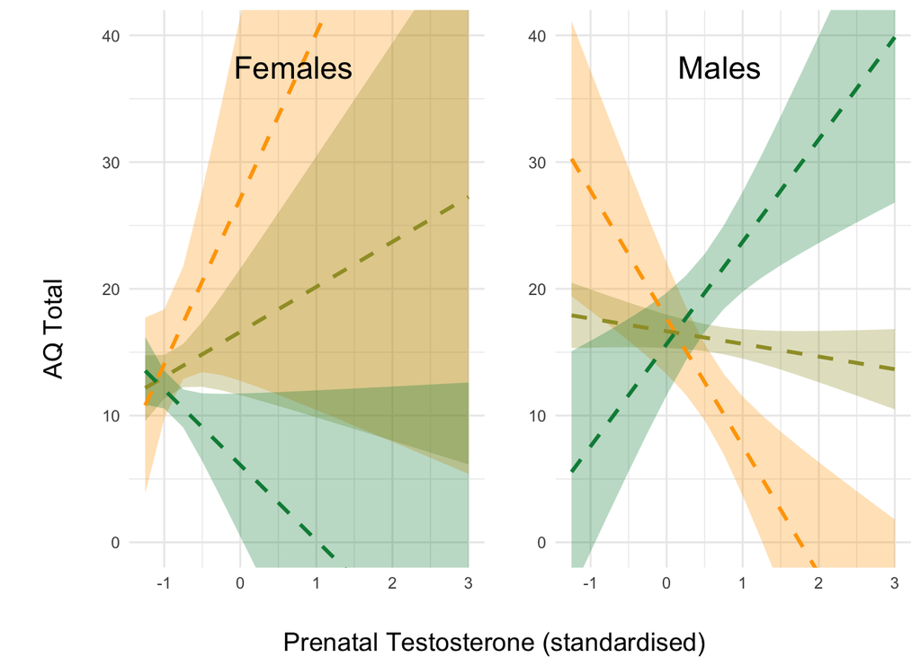

```r
# set colours
lcol <- "deepskyblue"
hcol <- "blue4"
lcol2 <- "turquoise"
hcol2 <- "darkcyan"
lcol3 <- "red"
hcol3 <- "darkred"
lcol4 <- "orange"
hcol4 <- "darkorange4"

lpub <-"orange"
hpub <- "springgreen4"


# M1. pubertal stage
boypred <- as.data.frame(effect(c("ftz", "pub.stage"), boy.AQ1b_,
                       xlevels= list(ftz = seq(from=-1.25, to=3, by=0.25),
                                     pub.stage = seq(from=2, to=4, by=1)),
                       se=TRUE, confidence.level = .95,
                       typical=mean))

girlpred <- as.data.frame(effect(c("ftz", "pub.stage"), girl.AQ1b_,
                       xlevels= list(ftz = seq(from=-1.25, to=3, by=0.25),
                                     pub.stage = seq(from=2, to=4, by=1)),
                       se=TRUE, confidence.level = .95,
                       typical=mean))
boy1 <- ggplot()+
  #geom_point(data = dboys, aes(x=ftz, y=AQ, colour=pub.stage))+
  geom_ribbon(data = boypred, aes(x = ftz, ymin = fit - se, ymax = fit + se,
              group=pub.stage, fill=pub.stage), alpha = 0.3) +
  geom_line(data = boypred, aes(x = ftz, y = fit,
               group=pub.stage, colour=pub.stage), size=1, linetype="dashed") +
  labs(x = "", y = "", fill = "Male\nPubertal Stage", colour = "Male\nPubertal Stage") +
  scale_colour_gradient(low=lpub, high=hpub)+
  scale_fill_gradient(low=lpub, high=hpub)+
  coord_cartesian(ylim = c(0,40)) +
  theme_minimal() +
  theme(legend.position = "none")+
  annotate("text", label = "Males", x = 0.7, y = 37.5, size = 6, colour = "black")

girl1 <- ggplot()+
  #geom_point(data = dgirls, aes(x=ftz, y=AQ, colour=pub.stage))+
  geom_ribbon(data = girlpred, aes(x = ftz, ymin = fit - se, ymax = fit + se,
              group=pub.stage, fill=pub.stage), alpha = 0.3) +
  geom_line(data = girlpred, aes(x = ftz, y = fit,
            group=pub.stage, colour=pub.stage), size=1,linetype="dashed") +
  labs(x = "", y = "", fill = "Female\nPubertal Stage", colour = "Female\nPubertal Stage") +
  scale_colour_gradient(low=lpub, high=hpub)+
  scale_fill_gradient(low=lpub, high=hpub)+
  coord_cartesian(ylim = c(0,40)) +
  theme_minimal() +
  theme(legend.position = "none")+
  annotate("text", label = "Females", x = 0.7, y = 37.5, size = 6, colour = "black")

p1<-ggarrange(girl1, boy1,  nrow=1, ncol=2)
annotate_figure(p1,
                left = text_grob("\nAQ Total", rot=90, size=14),
                bottom = text_grob("Prenatal Testosterone (standardised)", size=14))
```

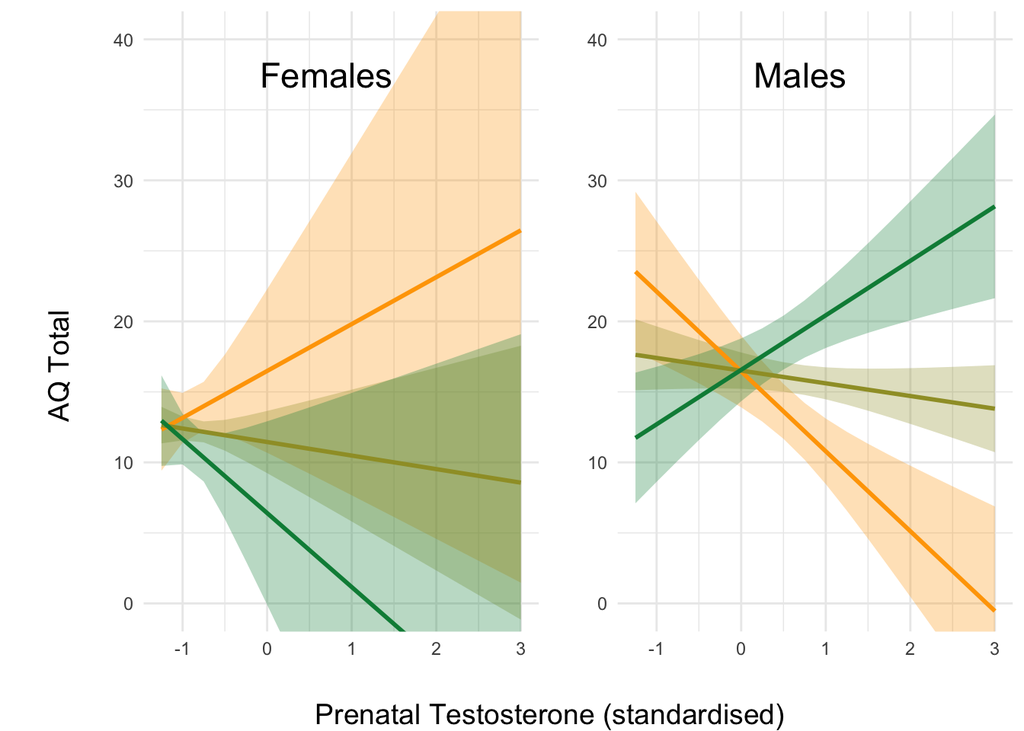

```r
# M2. pubertal timing
boypred <- as.data.frame(effect(c("ftz", "pub.timing"), boy.AQ2b,
                       xlevels= list(ftz = seq(from=-1.25, to=3, by=0.25),
                                     pub.timing = seq(from=-0.5, to=0.5, by=0.5)),
                       se=TRUE, confidence.level = .95,
                       typical=mean))

girlpred <- as.data.frame(effect(c("ftz", "pub.timing"), girl.AQ2b,
                       xlevels= list(ftz = seq(from=-1.25, to=3, by=0.25),
                                     pub.timing = seq(from=-0.5, to=0.5, by=0.5)),
                       se=TRUE, confidence.level = .95,
                       typical=mean))

boy2 <- ggplot()+
  geom_ribbon(data = boypred, aes(x = ftz, ymin = fit - se, ymax = fit + se,
              group=pub.timing, fill=pub.timing), alpha = 0.3) +
  geom_line(data = boypred, aes(x = ftz, y = fit,
               group=pub.timing, colour=pub.timing), size=1) +
  labs(x = "", y = "", fill = "Male\nPubertal Timing", colour = "Male\nPubertal Timing") +
  scale_colour_gradient(low=lpub, high=hpub)+
  scale_fill_gradient(low=lpub, high=hpub)+
  coord_cartesian(ylim = c(0,40)) +
  theme_minimal() +
  theme(legend.position = "none")+
  annotate("text", label = "Males", x = 0.7, y = 37.5, size = 6, colour = "black")

girl2 <- ggplot()+
  geom_ribbon(data = girlpred, aes(x = ftz, ymin = fit - se, ymax = fit + se,
              group=pub.timing, fill=pub.timing), alpha = 0.3) +
  geom_line(data = girlpred, aes(x = ftz, y = fit,
            group=pub.timing, colour=pub.timing), size=1) +
  labs(x = "", y = "", fill = "Female\nPubertal Timing", colour = "Female\nPubertal Timing") +
  scale_colour_gradient(low=lpub, high=hpub)+
  scale_fill_gradient(low=lpub, high=hpub)+
  coord_cartesian(ylim = c(0,40)) +
  theme_minimal() +
  theme(legend.position = "none")+
  annotate("text", label = "Females", x = 0.7, y = 37.5, size = 6, colour = "black")

p3<-ggarrange(girl2, boy2,  nrow=1, ncol=2)
annotate_figure(p3,
          left = text_grob("\nAQ Total", rot=90, size=14),
          bottom = text_grob("Prenatal Testosterone (standardised)", size=14))
```

## Sensitivity Analysis 3: generalized linear mixed models

```r
M1a.AQ.gamma <- glmer(AQ ~ ftz  + GENDER + rater + pub.stage.z
                     + ftz:GENDER
                     + ftz:pub.stage.z
                     + (1 | ID),
                     data = d,
                     contrasts=list(GENDER=c(-0.5,0.5), rater=c(-0.5,0.5)),
                     family = Gamma(link=identity),
                     control = glmerControl(optimizer = "bobyqa" ,
                                      optCtrl = list(maxfun= 100000)),
                     nAGQ = 20)
M1b.AQ.gamma <- glmer(AQ ~ ftz  + GENDER + rater + pub.stage.z
                     + ftz:GENDER
                     + ftz:pub.stage.z  + mat.age.z
                     + (1 | ID),
                     data = d,
                     contrasts=list(GENDER=c(-0.5,0.5), rater=c(-0.5,0.5)),
                     family = Gamma(link=identity),
                     control = glmerControl(optimizer = "bobyqa" ,
                                      optCtrl = list(maxfun= 100000)),
                     nAGQ = 20)
M1c.AQ.gamma <- glmer(AQ ~ ftz  + GENDER + rater + pub.stage.z
                     + ftz:GENDER
                     + ftz:pub.stage.z   + mat.age.z + GA.z
                     + (1 | ID),
                     data = d,
                     contrasts=list(GENDER=c(-0.5,0.5), rater=c(-0.5,0.5)),
                     family = Gamma(link=identity),
                     control = glmerControl(optimizer = "bobyqa" ,
                                      optCtrl = list(maxfun= 100000)),
                     nAGQ = 20)

stargazer(M1a.AQ.gamma, M1b.AQ.gamma, M1c.AQ.gamma, digits = 2, report = ('vcstp'),  digit.separator = "",  align = TRUE,    type = "text")
```

```
##
## ==============================================
##                      Dependent variable:
##                 ------------------------------
##                               AQ
##                    (1)       (2)       (3)
## ----------------------------------------------
## ftz               -0.87     -0.79     -2.95
##                  (1.44)    (1.60)     (3.32)
##                 t = -0.60 t = -0.50 t = -0.89
##                 p = 0.55  p = 0.63   p = 0.38
##
## GENDER1           5.99      4.79       7.09
##                  (2.73)    (2.96)     (6.82)
##                 t = 2.19  t = 1.62   t = 1.04
##                 p = 0.03  p = 0.11   p = 0.30
##
## rater1            -4.67     -4.71     -4.01
##                  (0.69)    (0.77)     (0.98)
##                 t = -6.81 t = -6.11 t = -4.10
##                 p = 0.00  p = 0.00  p = 0.0001
##
## pub.stage.z       1.13      0.69      -1.66
##                  (1.64)    (1.80)     (2.70)
##                 t = 0.69  t = 0.38  t = -0.61
##                 p = 0.50  p = 0.71   p = 0.54
##
## mat.age.z                   -0.04     -0.11
##                            (0.14)     (0.19)
##                           t = -0.29 t = -0.56
##                           p = 0.78   p = 0.58
##
## GA.z                                  -1.52
##                                       (0.59)
##                                     t = -2.59
##                                      p = 0.01
##
## ftz:GENDER1       1.75      1.96       9.69
##                  (3.03)    (3.25)     (6.56)
##                 t = 0.58  t = 0.60   t = 1.48
##                 p = 0.57  p = 0.55   p = 0.14
##
## ftz:pub.stage.z   2.86      3.44       5.98
##                  (2.09)    (2.24)     (3.25)
##                 t = 1.37  t = 1.54   t = 1.84
##                 p = 0.18  p = 0.13   p = 0.07
##
## Constant          13.10     13.24     10.83
##                  (1.30)    (1.40)     (3.15)
##                 t = 10.11 t = 9.46   t = 3.44
##                 p = 0.00  p = 0.00  p = 0.001
##
## ----------------------------------------------
## Observations       170       139        94
## ==============================================
## Note:              *p<0.1; **p<0.05; ***p<0.01
```

```r
M2a.AQ.gamma <- glmer(AQ ~ ftz  + GENDER + rater + pub.timing
                     + ftz:GENDER
                     + ftz:pub.timing
                     + (1 | ID),
                     data = d,
                     contrasts=list(GENDER=c(-0.5,0.5), rater=c(-0.5,0.5)),
                     family = Gamma(link=identity),
                     control = glmerControl(optimizer = "bobyqa" ,
                                      optCtrl = list(maxfun= 100000)),
                     nAGQ = 20)
M2b.AQ.gamma <- glmer(AQ ~ ftz  + GENDER + rater + pub.timing
                     + ftz:GENDER
                     + ftz:pub.timing + mat.age.z
                     + (1 | ID),
                     data = d,
                     contrasts=list(GENDER=c(-0.5,0.5), rater=c(-0.5,0.5)),
                     family = Gamma(link=identity),
                     control = glmerControl(optimizer = "bobyqa" ,
                                      optCtrl = list(maxfun= 100000)),
                     nAGQ = 20)

M2c.AQ.gamma <- glmer(AQ ~ ftz  + GENDER + rater + pub.timing
                     + ftz:GENDER
                     + ftz:pub.timing + mat.age.z + GA.z
                     + (1 | ID),
                     data = d,
                     contrasts=list(GENDER=c(-0.5,0.5), rater=c(-0.5,0.5)),
                     family = Gamma(link=identity),
                     control = glmerControl(optimizer = "bobyqa" ,
                                      optCtrl = list(maxfun= 100000)),
                     nAGQ = 20)

stargazer(M2a.AQ.gamma, M2b.AQ.gamma, M2c.AQ.gamma, digits = 2, report = ('vcstp'),  digit.separator = "",  align = TRUE,    type = "text")
```

```
##
## =============================================
##                     Dependent variable:
##                ------------------------------
##                              AQ
##                   (1)       (2)       (3)
## ---------------------------------------------
## ftz              -0.89     -0.85     -3.17
##                 (1.44)    (1.59)     (3.30)
##                t = -0.62 t = -0.54 t = -0.96
##                p = 0.54  p = 0.60   p = 0.34
##
## GENDER1          5.40      4.40       8.24
##                 (2.56)    (2.76)     (6.19)
##                t = 2.11  t = 1.60   t = 1.33
##                p = 0.04  p = 0.12   p = 0.19
##
## rater1           -4.66     -4.70     -4.05
##                 (0.68)    (0.77)     (0.97)
##                t = -6.84 t = -6.12 t = -4.16
##                p = 0.00  p = 0.00  p = 0.0001
##
## pub.timing       1.63      0.95      -1.18
##                 (1.98)    (2.05)     (2.85)
##                t = 0.82  t = 0.46  t = -0.41
##                p = 0.42  p = 0.65   p = 0.68
##
## mat.age.z                  -0.01     -0.08
##                           (0.14)     (0.20)
##                          t = -0.09 t = -0.39
##                          p = 0.93   p = 0.71
##
## GA.z                                 -1.51
##                                      (0.58)
##                                    t = -2.62
##                                     p = 0.01
##
## ftz:GENDER1      0.17      0.04       6.42
##                 (2.88)    (3.08)     (6.60)
##                t = 0.06  t = 0.01   t = 0.97
##                p = 0.96  p = 0.99   p = 0.34
##
## ftz:pub.timing   3.71      4.54       6.61
##                 (2.32)    (2.45)     (3.36)
##                t = 1.60  t = 1.85   t = 1.97
##                p = 0.11  p = 0.07   p = 0.05
##
## Constant         13.06     13.21     10.85
##                 (1.29)    (1.39)     (3.17)
##                t = 10.16 t = 9.51   t = 3.43
##                p = 0.00  p = 0.00  p = 0.001
##
## ---------------------------------------------
## Observations      170       139        94
## =============================================
## Note:             *p<0.1; **p<0.05; ***p<0.01
```

# AQ subscale analysis

```r
# Put all (standardized) outcome sub-scales together in DVlist
DVlist <- c("SOCIAL", "ATT_SWITCH", "COMMUNIC", "IMAGIN", "DETAIL")

X = length(DVlist)

contrasts(d$GENDER) <- c(-.5, .5)
contrasts(d$rater) <- c(-.5, .5)
```

```r
# pubertal stage model
M1a.outcomes.lme <- lapply(DVlist, function(x) {
lmer(eval(substitute(i ~ ftz  + GENDER + rater + pub.stage.z
                      + ftz:GENDER + ftz:pub.stage.z
                      + (1|ID),
                list(i = as.name(x)))),
              data = d)})

M1b.outcomes.lme <- lapply(DVlist, function(x) {
lmer(eval(substitute(i ~ ftz  + GENDER + rater + pub.stage.z
                      + ftz:GENDER + ftz:pub.stage.z + mat.age.z
                      + (1|ID),
                list(i = as.name(x)))),
              data = d)})

M1c.outcomes.lme <- lapply(DVlist, function(x) {
lmer(eval(substitute(i ~ ftz  + GENDER + rater + pub.stage.z
                      + ftz:GENDER + ftz:pub.stage.z + mat.age.z + GA.z
                      + (1|ID),
                list(i = as.name(x)))),
              data = d)})

# pubertal timing models
M2a.outcomes.lme <- lapply(DVlist, function(x) {
lmer(eval(substitute(i ~ ftz  + GENDER + rater + pub.timing
                      + ftz:GENDER + ftz:pub.timing
                      + (1|ID),
                list(i = as.name(x)))),
              data = d)})

M2b.outcomes.lme <- lapply(DVlist, function(x) {
lmer(eval(substitute(i ~ ftz  + GENDER + rater + pub.timing
                      + ftz:GENDER + ftz:pub.timing + mat.age.z
                      + (1|ID),
                list(i = as.name(x)))),
              data = d)})

M2c.outcomes.lme <- lapply(DVlist, function(x) {
lmer(eval(substitute(i ~ ftz  + GENDER + rater + pub.timing
                      + ftz:GENDER + ftz:pub.timing + mat.age.z + GA.z
                      + (1|ID),
                list(i = as.name(x)))),
              data = d)})
```

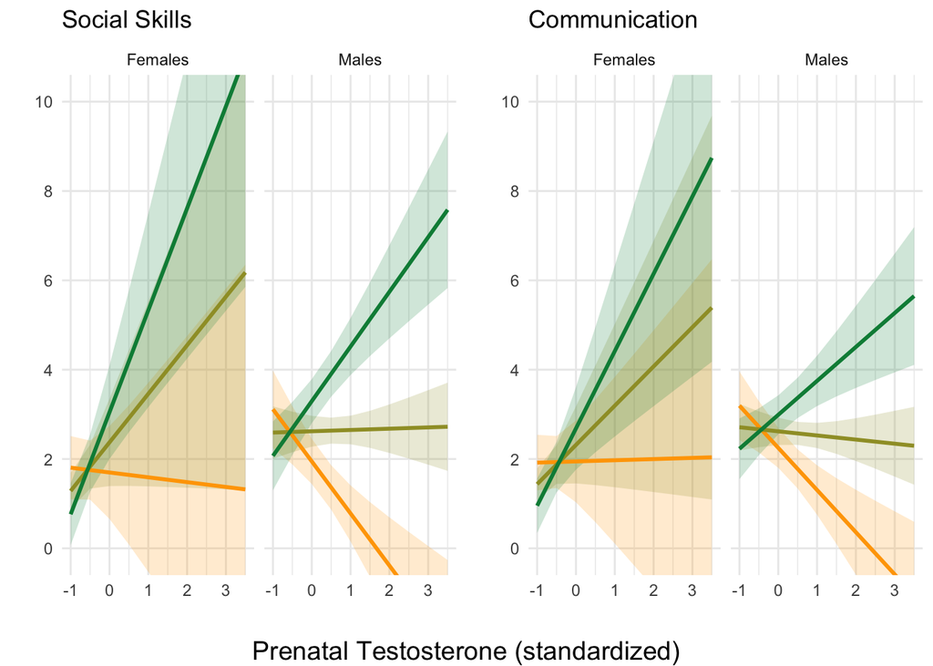

```r
lpub <-"orange"
hpub <- "springgreen4"

DVlist.nice <- c("Social Skills", "Attention-Switching", "Communication", "Imagination", "Attention to Detail")

plot_list <- vector("list", length = length(DVlist.nice))


for (X in 1:length(DVlist.nice)) {
predicted <- effect(c("ftz", "pub.timing", "GENDER"), M2b.outcomes.lme[[X]],
                       xlevels= list(ftz = seq(from=-1, to=3.5, by=0.5),
                                     pub.timing=seq(from=-.5, to=.5, by=0.5)),
                       se=TRUE, confidence.level = .95,
                       typical=mean)
pred.df <- as.data.frame(predicted)
pred.df$GENDER = relevel(pred.df$GENDER, "girl")
levels(pred.df$GENDER) <- c("Females", "Males")
pred.df$GENDER <- droplevels(pred.df$GENDER)

dv.col <- which(names(d)==DVlist[X])

p <- ggplot() +
  geom_ribbon(data= pred.df, aes(x = ftz, ymin = fit - se, ymax = fit + se,
                  group=pub.timing, fill=pub.timing), alpha = 0.2) +
  geom_line(data= pred.df,aes(x = ftz, y = fit, group = pub.timing, colour=pub.timing),size=1) +
  labs(x = "", y = paste(DVlist.nice[X]),
       title = paste(DVlist.nice[X])) +
  scale_y_discrete(name = "", limits = c(0,2,4,6,8,10),
                   labels = c("0", "2", "4", "6", "8", "10"))+
  coord_cartesian(ylim = c(0, 10)) +
  scale_colour_gradient(low=lpub, high=hpub)+
  scale_fill_gradient(low=lpub, high=hpub)+
  theme_minimal()+
  theme(legend.position = "none")+
  facet_grid(~GENDER)


plot_list[[X]] <- p
}
gg<-ggarrange(plot_list[[1]], plot_list[[3]], nrow = 1, ncol=2)
annotate_figure(gg,
                bottom = text_grob("Prenatal Testosterone (standardized)",
                                   hjust=0.5, size=14))
```

```r
DVlist.nice <- c("Social Skills", "Attention-Switching", "Communication", "Imagination", "Attention to Detail")

plot_list <- vector("list", length = length(DVlist.nice))


for (X in 1:length(DVlist.nice)) {
predicted <- effect(c("ftz", "pub.timing"), M2b.outcomes.lme[[X]],
                       xlevels= list(ftz = seq(from=-1, to=3.5, by=0.5),
                                     pub.timing=seq(from=-.5, to=.5, by=0.5)),
                       se=TRUE, confidence.level = .95,
                       typical=mean)
pred.df <- as.data.frame(predicted)


p <- ggplot() +
  geom_ribbon(data= pred.df, aes(x = ftz, ymin = fit - se, ymax = fit + se,
                  group=pub.timing, fill=pub.timing), alpha = 0.3) +
  geom_line(data= pred.df,aes(x = ftz, y = fit, group = pub.timing, colour=pub.timing),size=1) +
  labs(x = "", y = paste(DVlist.nice[X]),
       title = paste(DVlist.nice[X]), fill = "Pubertal Timing", colour= "Pubertal Timing") +
  scale_y_discrete(name = "", limits = c(0,2,4,6,8,10),
                   labels = c("0", "2", "4", "6", "8", "10"))+
  scale_colour_gradient(low="orange", high="springgreen4")+
  scale_fill_gradient(low="orange", high="springgreen4")+
  coord_cartesian(ylim = c(1, 11)) +
  theme_minimal()+
  theme(legend.position = "none", plot.title = element_text(face = "bold"))


plot_list[[X]] <- p
}
```

```
## NOTE: ftzpub.timing is not a high-order term in the model
```

```
## NOTE: ftzpub.timing is not a high-order term in the model
```

```
## NOTE: ftzpub.timing is not a high-order term in the model
```

```
## NOTE: ftzpub.timing is not a high-order term in the model
```

```
## NOTE: ftzpub.timing is not a high-order term in the model
```

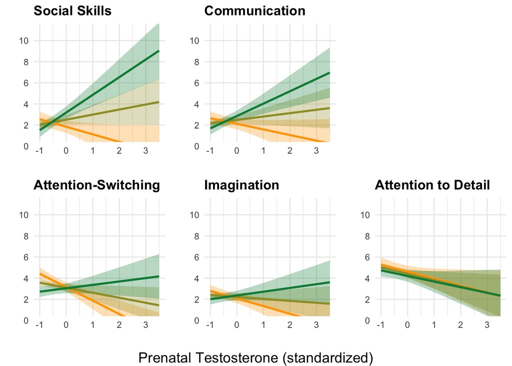

```r
gg_top<-ggarrange(plot_list[[1]], plot_list[[3]], nrow = 1, ncol=3)
gg_bottom<-ggarrange(plot_list[[2]],  plot_list[[4]],plot_list[[5]], nrow = 1, ncol=3)
gg_all <- ggarrange(gg_top, gg_bottom, nrow=2, ncol=1)
annotate_figure(gg_all,
                bottom = text_grob("Prenatal Testosterone (standardized)",
                                   hjust=0.5, size=14))
```

## Subscore Sensitivity Analysis 1: sex-stratify

```r
contrasts(dboys$rater) <- c(-.5, .5)
contrasts(dgirls$rater) <- c(-.5, .5)

# NOTE: ft:rater is excluded

boyM2.lme <- lapply(DVlist, function(x) {
  lmer(eval(substitute(i ~ ftz  + rater + pub.timing
                      + ftz:pub.timing + (1 | ID),
                        list(i = as.name(x)))),
        data = dboys)})


girlM2.lme <- lapply(DVlist, function(x) {
  lmer(eval(substitute(i ~ ftz  + rater + pub.timing
                         + ftz:pub.timing + (1 | ID),
                        list(i = as.name(x)))),
        data = dgirls)})


stargazer(boyM2.lme[[1]], boyM2.lme[[2]], boyM2.lme[[3]], boyM2.lme[[4]], boyM2.lme[[5]], column.labels =
         c("boy","boy", "boy", "boy", "boy"),
 digits = 2, report=('vcsp'), digit.separator = "", order = c(), align = TRUE,    type = "text")
```

```
##
## ==================================================================
##                                  Dependent variable:
##                     ----------------------------------------------
##                      SOCIAL  ATT_SWITCH COMMUNIC  IMAGIN   DETAIL
##                       boy       boy       boy      boy      boy
##                       (1)       (2)       (3)      (4)      (5)
## ------------------------------------------------------------------
## ftz                  -0.17     -0.31     -0.37    -0.11    -0.50
##                      (0.35)    (0.28)    (0.29)   (0.25)   (0.29)
##                     p = 0.63  p = 0.27  p = 0.21 p = 0.67 p = 0.09
##
## rater1               -0.01     -1.08     -0.12    -0.02    -0.85
##                      (0.38)    (0.39)    (0.37)   (0.37)   (0.39)
##                     p = 0.99  p = 0.01  p = 0.75 p = 0.96 p = 0.04
##
## pub.timing           -0.15      0.33      0.46     0.30    -1.59
##                      (1.31)    (1.02)    (1.07)   (0.93)   (1.09)
##                     p = 0.92  p = 0.75  p = 0.67 p = 0.76 p = 0.15
##
## ftz:pub.timing        3.62      0.81      1.85     1.01     1.46
##                      (1.51)    (1.17)    (1.23)   (1.07)   (1.25)
##                     p = 0.02  p = 0.49  p = 0.14 p = 0.35 p = 0.25
##
## Constant              2.82      4.08      2.80     2.94     4.79
##                      (0.38)    (0.30)    (0.31)   (0.27)   (0.32)
##                     p = 0.00  p = 0.00  p = 0.00 p = 0.00 p = 0.00
##
## ------------------------------------------------------------------
## Observations           96        96        96       96       96
## Log Likelihood      -216.98   -205.85   -206.07  -199.64  -209.01
## Akaike Inf. Crit.    447.95    425.70    426.14   413.28   432.02
## Bayesian Inf. Crit.  465.90    443.65    444.09   431.23   449.97
## ==================================================================
## Note:                                  *p<0.1; **p<0.05; ***p<0.01
```

```r
stargazer(girlM2.lme[[1]], girlM2.lme[[2]], girlM2.lme[[3]], girlM2.lme[[4]], girlM2.lme[[5]], column.labels =
         c("girl","girl", "girl", "girl", "girl"),
 digits = 2, report=('vcsp'), digit.separator = "", order = c(), align = TRUE,    type = "text")
```

```
##
## ========================================================================
##                                     Dependent variable:
##                     ----------------------------------------------------
##                      SOCIAL   ATT_SWITCH COMMUNIC    IMAGIN     DETAIL
##                       girl       girl      girl       girl       girl
##                        (1)       (2)        (3)       (4)        (5)
## ------------------------------------------------------------------------
## ftz                   0.68      -0.69      0.74      -0.15      -1.45
##                      (0.68)     (0.67)    (0.71)     (0.54)     (0.91)
##                     p = 0.32   p = 0.31  p = 0.30   p = 0.78   p = 0.12
##
## rater1                -1.00     -1.57      -0.67     -1.09      -1.35
##                      (0.32)     (0.37)    (0.35)     (0.26)     (0.39)
##                     p = 0.002 p = 0.0001 p = 0.06  p = 0.0001 p = 0.001
##
## pub.timing            0.75      -1.17      5.23      -2.84      -4.25
##                      (3.17)     (3.17)    (3.32)     (2.52)     (4.25)
##                     p = 0.82   p = 0.72  p = 0.12   p = 0.27   p = 0.32
##
## ftz:pub.timing        0.45       0.14      6.42      -2.43      -6.12
##                      (3.60)     (3.59)    (3.77)     (2.86)     (4.83)
##                     p = 0.91   p = 0.97  p = 0.09   p = 0.40   p = 0.21
##
## Constant              1.93       2.30      2.09       1.36       3.39
##                      (0.59)     (0.59)    (0.62)     (0.47)     (0.79)
##                     p = 0.002 p = 0.0001 p = 0.001 p = 0.004  p = 0.0001
##
## ------------------------------------------------------------------------
## Observations           74         74        74         74         74
## Log Likelihood       -130.57   -135.47    -135.19   -116.03    -148.03
## Akaike Inf. Crit.    275.14     284.95    284.38     246.06     310.05
## Bayesian Inf. Crit.  291.27     301.07    300.50     262.19     326.18
## ========================================================================
## Note:                                        *p<0.1; **p<0.05; ***p<0.01
```

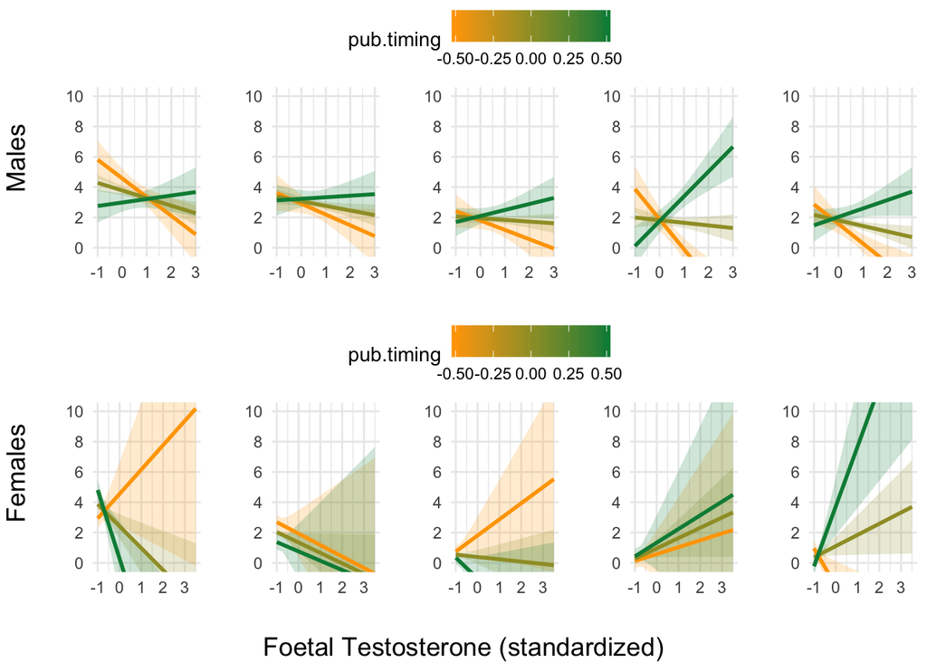

```r
DVlist.nice <- c("Social Skills", "Attention-Switching", "Communication", "Imagination", "Attention to Detail")

boy_list <- vector("list", length = length(DVlist.nice))
girl_list <- vector("list", length = length(DVlist.nice))


for (X in 1:5) {

## BOYS ##

boypred <- as.data.frame(effect(c("ftz", "pub.timing"), boyM2.lme[[X]],
                       xlevels= list(ftz = seq(from=-1, to=3, by=0.25),
                                     pub.timing=seq(from=-.5, to=.5, by=0.5)),
                       se=TRUE, confidence.level = .95,
                       typical=mean))


boyp <- ggplot() +
  geom_ribbon(data= boypred, aes(x = ftz, ymin = fit - se, ymax = fit + se,
                  group=pub.timing, fill=pub.timing), alpha = 0.2) +
  geom_line(data= boypred,aes(x = ftz, y = fit,
              group = pub.timing, colour=pub.timing),size=1) +
  labs(x = "") +
  scale_y_discrete(name = "", limits = c(1,3,5,7,9,11),
                   labels = c("0", "2", "4", "6", "8", "10"))+
  coord_cartesian(ylim = c(1, 11)) +
  scale_colour_gradient(low=lpub, high=hpub)+
  scale_fill_gradient(low=lpub, high=hpub)+
  theme_minimal()+
  theme(legend.position = "none", plot.title = element_text(face = "bold"))

boy_list[[X]] <- boyp

## GIRLS ##

girlpred <- as.data.frame(effect(c("ftz", "pub.timing"), girlM2.lme[[X]],
                       xlevels= list(ftz = seq(from=-1, to=3.5, by=0.25),
                                     pub.timing=seq(from=-.5, to=.5, by=0.5)),
                       se=TRUE, confidence.level = .95,
                       typical=mean))
girlp <- ggplot() +
  geom_ribbon(data= girlpred, aes(x = ftz, ymin = fit - se, ymax = fit + se,
                  group=pub.timing, fill=pub.timing), alpha = 0.2) +
  geom_line(data= girlpred,aes(x = ftz, y = fit,
                      group = pub.timing, colour=pub.timing),size=1) +
  scale_y_discrete(name = "", limits = c(1,3,5,7,9,11),
                   labels = c("0", "2", "4", "6", "8", "10"))+
  labs(x="")+
  scale_colour_gradient(low=lpub, high=hpub)+
  scale_fill_gradient(low=lpub, high=hpub)+
  coord_cartesian(ylim = c(1, 11)) +
  theme_minimal()+
  theme(legend.position = "none",plot.title = element_text(face = "bold"))


girl_list[[X]] <- girlp
}

gboy<-ggarrange(boy_list[[5]],  boy_list[[2]], boy_list[[4]], boy_list[[1]],boy_list[[3]],
                nrow = 1, ncol=5, common.legend = T)
gboy<-annotate_figure(gboy,
                      left = text_grob("Males",
                                   size=14, rot = 90))

ggirl<-ggarrange(girl_list[[5]],girl_list[[2]],girl_list[[4]],girl_list[[1]],girl_list[[3]],
                nrow = 1, ncol=5, common.legend = T)
ggirl<-annotate_figure(ggirl,
                      left = text_grob("Females",
                                   size=14, rot = 90))

gg <- ggarrange (gboy, ggirl, nrow=2, ncol=1, common.legend = T)
annotate_figure(gg,
                bottom = text_grob("Foetal Testosterone (standardized)",
                                   hjust=0.5, size=14))
```

## Subscore Sensitivity Analysis 2: generalized linear mixed models

```r
d$SOCIALplus = d$SOCIAL+1
d$ATT_SWITCHplus = d$ATT_SWITCH+1
d$COMMUNICplus = d$COMMUNIC+1
d$IMAGINplus = d$IMAGIN+1
d$DETAILplus = d$DETAIL+1

DVlist <- c("SOCIALplus") # GLMM only run for social skills as this was the only subscale significant in LMMs


# M2a.outcomes.glmm <- lapply(DVlist, function(x) {
# glmer(eval(substitute(i ~ ftz  + GENDER + rater + pub.timing
#                          + ftz:GENDER + ftz:pub.timing
#                       + (1|ID),
#                 list(i = as.name(x)))),
#               data = d,
#               family = Gamma(link=identity),
#               control = glmerControl(optimizer = "bobyqa" ,
#                                       optCtrl = list(maxfun= 100000)),
#                      nAGQ = 20)})
# did not converge

M2b.outcomes.glmm <- lapply(DVlist, function(x) {
glmer(eval(substitute(i ~ ftz  + GENDER + rater + pub.timing
                         + ftz:GENDER + ftz:pub.timing + mat.age.z
                      + (1|ID),
                list(i = as.name(x)))),
              data = d,
              family = Gamma(link=identity),
              control = glmerControl(optimizer = "bobyqa" ,
                                      optCtrl = list(maxfun= 100000)),
                     nAGQ = 20)})

M2c.outcomes.glmm <- lapply(DVlist, function(x) {
glmer(eval(substitute(i ~ ftz  + GENDER + rater + pub.timing
                         + ftz:GENDER + ftz:pub.timing + mat.age.z + GA.z
                      + (1|ID),
                list(i = as.name(x)))),
              data = d,
              family = Gamma(link=identity),
              control = glmerControl(optimizer = "bobyqa" ,
                                      optCtrl = list(maxfun= 100000)),
                     nAGQ = 20)})

# run M2a-c as glmmPQLs just to validate glmer findings
M2a.outcomes.pql <- lapply(DVlist, function(x) {
glmmPQL(eval(substitute(i ~ ftz  + GENDER + rater + pub.timing
                        + ftz:GENDER + ftz:pub.timing,
                list(i = as.name(x)))),
              random =  ~1|ID,
              data = d,
              family = Gamma(link="identity"),
              verbose=0)})
M2b.outcomes.pql <- lapply(DVlist, function(x) {
glmmPQL(eval(substitute(i ~ ftz  + GENDER + rater + pub.timing
                        + ftz:GENDER + ftz:pub.timing + mat.age.z,
                list(i = as.name(x)))),
              random =  ~1|ID,
              data = d,
              family = Gamma(link="identity"),
              verbose=0)})
M2c.outcomes.pql <- lapply(DVlist, function(x) {
glmmPQL(eval(substitute(i ~ ftz  + GENDER + rater + pub.timing
                        + ftz:GENDER + ftz:pub.timing + mat.age.z + GA.z,
                list(i = as.name(x)))),
              random =  ~1|ID,
              data = d,
              family = Gamma(link="identity"),
              verbose=0)})

# social skills
 stargazer(M2b.outcomes.glmm[[1]], M2c.outcomes.glmm[[1]], report = ('vctsp'),
  digits = 2, digit.separator = "",  align = TRUE,    type = "text")
```

```
##
## ===========================================
##                    Dependent variable:
##                ----------------------------
##                         SOCIALplus
##                     (1)            (2)
## -------------------------------------------
## ftz                 0.37          -0.20
##                   t = 0.74      t = -0.22
##                    (0.50)        (0.93)
##                   p = 0.46      p = 0.83
##
## GENDER1             0.26          0.96
##                   t = 0.29      t = 0.55
##                    (0.88)        (1.74)
##                   p = 0.78      p = 0.59
##
## rater1             -0.48          -0.21
##                  t = -2.39      t = -0.86
##                    (0.20)        (0.24)
##                   p = 0.02      p = 0.40
##
## pub.timing          0.65          -0.65
##                   t = 1.09      t = -0.84
##                    (0.60)        (0.77)
##                   p = 0.28      p = 0.40
##
## mat.age.z          -0.001         0.04
##                  t = -0.03      t = 0.64
##                    (0.04)        (0.06)
##                   p = 0.98      p = 0.53
##
## GA.z                              -0.12
##                                 t = -0.71
##                                  (0.18)
##                                 p = 0.49
##
## ftz:GENDER1        -0.48          0.71
##                  t = -0.49      t = 0.38
##                    (0.98)        (1.86)
##                   p = 0.63      p = 0.71
##
## ftz:pub.timing      1.52          3.01
##                   t = 2.15      t = 3.27
##                    (0.71)        (0.92)
##                   p = 0.04      p = 0.002
##
## Constant            2.86          2.72
##                   t = 6.47      t = 3.05
##                    (0.44)        (0.89)
##                   p = 0.00      p = 0.003
##
## -------------------------------------------
## Observations        139            94
## ===========================================
## Note:           *p<0.1; **p<0.05; ***p<0.01
```